# Classification and Clustering: Case Study with CRC Gene Expression Data

## 3.3 Dataset Cleaning

Following a peek into the datasets, we will proceed forward keeping only the datasets which used the HG-U133_Plus_2 gene chip (N=54675 probe sets) and have msi status: GSE13067, GSE13294, GSE35896, GSE39084, GSE4554

We exclude GSE75316 from the analysis as most of the samples are already part of GSE13067 and the latter is a larger set.

In the next chunk, we go through each of these datasets and store the gene expression and sample description data in a uniform manner to facilitate subsequent pooling. We also take a look at potential intra dataset batch effects.

```
##
##
## Processing  GSE13067
## MS_Status
## MSI MSS
##  11  63
```

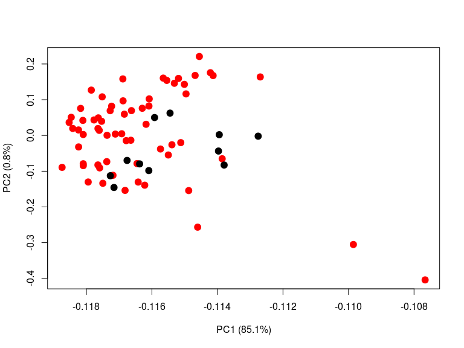

```
##
##
## Processing  GSE13294
## MS_Status
## MSI MSS
##  78  77
```

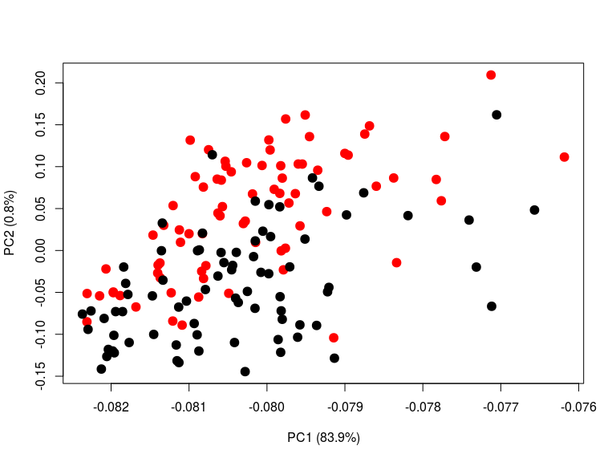

```
##
##
## Processing  GSE35896
## MS_Status
## --- MSI MSS
##   1   5  56
```

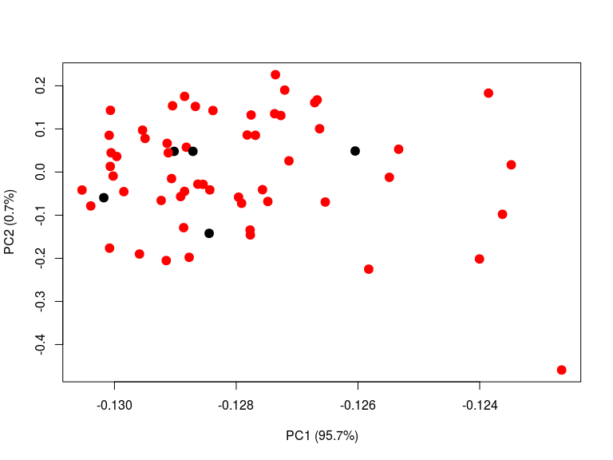

```
##
##
## Processing  GSE39084
## MS_Status
## High  Low   No
##   16    3   51
```

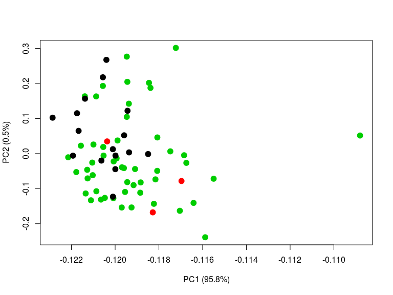

```
##
##
## Processing  GSE4554
## MS_Status
##               MSI               MSS Training-Lymph(-)
##                33                50                 1
```

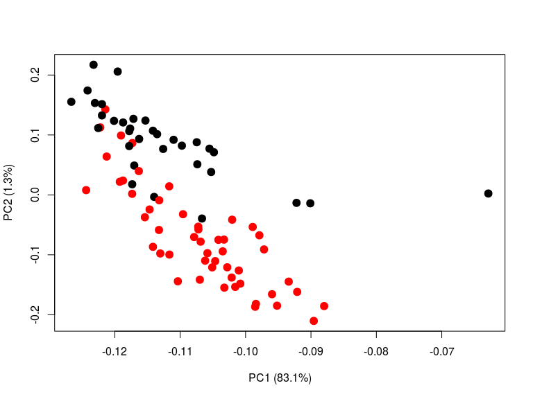

```r
 # CHANGE THIS LINE TO CLEAR CACHE ..
 suppressMessages(require(hgu133plus2.db))

 for(SET in KEEP_GSE.vec){
  cat("\n\nProcessing ", SET, '\n')

  loadObj(paste0(SET, '.gse'), 'Set.gse')

  ###################################################################
  #  Expr - matrix
  #  - rows are features
  #  - columns are samples
  ###################################################################
  Expr.mtx <- exprs(Set.gse[[1]])

  if(SET %in% c('GSE4554', 'GSE4045'))  Expr.mtx <- log2(pmax(Expr.mtx, min(Expr.mtx[Expr.mtx>0])))

  ###################################################################
  #  SampAttr - data.frame
  #  - rows are samples
  #  - columns are atttibutes of the samples
  ###################################################################
  phenoData.frm <- phenoData(Set.gse[[1]])@data

  if(nrow(phenoData.frm) != ncol(Expr.mtx)) stop("Expression-sampAttr Mismatch for ", SET)

  MS_Status <- switch(SET,
      GSE13067 = gsub(' ','',
                 sapply(strsplit(phenoData.frm$title, split=':'), function(x) x[2])),
      GSE13294 = gsub(' ','',
                 sapply(strsplit(phenoData.frm$title, split=':'), function(x) x[2])),
      GSE35896 = gsub(' ','',
                 sapply(strsplit(phenoData.frm$characteristics_ch1.7, split=':'), function(x) x[2])),
      GSE39084 = gsub(' ','',
                 sapply(strsplit(phenoData.frm$characteristics_ch1.16, split=':'), function(x) x[2])),
      GSE4554 =  gsub(' ', '',
                 sapply(strsplit(as.character(phenoData.frm$description), split=','), function(x) x[1])),
        "ERROR")

  print(table(MS_Status))

  KEEP.ndx <- which(is.element(MS_Status, c('MSS', 'MSI', 'No', 'Low', 'High')))

  sampAttr.frm <- data.frame(Sample_Id=rownames(phenoData.frm),
                             MS_Status=MS_Status,
                             row.names=rownames(phenoData.frm))[KEEP.ndx,]
  Expr.mtx <- Expr.mtx[,rownames(sampAttr.frm)]

  ###################################################################
  #  featureAttr - data.frame
  #  - rows of featureAttr match rows of Expr mtx
  #  - columns of featureAttr are atttibutes of the features - eg geneSymbol
  ###################################################################
  # This deosn;t work!
  #featureAttr.frm <- featureData(Set.gse[[1]])@data
  #dim(featureAttr.frm)
  #Symbol.vec <- mget(featureAttr.frm$ID, hgu133plus2SYMBOL)
  #featureAttr.frm$Symbol <- Symbol.vec[rownames(featureAttr.frm)]

  Symbol.vec <- mget(rownames(Expr.mtx), hgu133plus2SYMBOL)
  featureAttr.frm <- data.frame(Symbol=unlist(Symbol.vec))
  rownames(featureAttr.frm) <- rownames(Expr.mtx)

  ###################################################
  # Save in arrayGeneExpr object
  ###################################################
  if(sum(colnames(Expr.mtx) != rownames(sampAttr.frm))) stop("Column order error")
  if(sum(rownames(Expr.mtx) != rownames(featureAttr.frm))) stop("Row order error")

  Set.arrayGeneExpr <-  list(exprData=NA, exprType=NA, Norm=NA,
                                   sampAttr=NA, featureAttr=NA)
  class(Set.arrayGeneExpr) <- "arrayGeneExpr"
  Set.arrayGeneExpr$exprData <- Expr.mtx
  Set.arrayGeneExpr$sampAttr <- sampAttr.frm
  Set.arrayGeneExpr$featureAttr <- featureAttr.frm

  saveObj(paste0(SET,'.arrayGeneExpr'), 'Set.arrayGeneExpr')

  ######################################################
  # Look for intra-set batch effects
  ######################################################
  Expt.prcomp <- prcomp(Expr.mtx)

  plot(x=Expt.prcomp$rotation[,'PC1'],
       xlab=paste0('PC1 (', round(100*summary(Expt.prcomp)$importance[2,"PC1"],1),'%)'),
       y=Expt.prcomp$rotation[,'PC2'],
       ylab=paste0('PC2 (', round(100*summary(Expt.prcomp)$importance[2,"PC2"],1),'%)'),
       pch=19, cex=1.5, col=as.numeric(as.factor(sampAttr.frm$MS_Status)))


 }
```

## 3.4 Data Pooling

When pooling data from different sources, we should make sure not to introduce batch effects into the mix. In the first instance we will simply pool the data sets together, and apply quantile normalization. This can be seen as a very weak form of batch effect correction and is a minimal requirement.

```r
 ###############################
 # Get feature attributes from one of the arrayGeneExpr objects
 ###############################
 loadObj(paste0(KEEP_GSE.vec[1],'.arrayGeneExpr'), 'Set.arrayGeneExpr')

 featureAttr.frm <- Set.arrayGeneExpr$featureAttr
 featureAttr.frm$Symbol[is.na(featureAttr.frm$Symbol)] <-
        rownames(featureAttr.frm)[is.na(featureAttr.frm$Symbol)]
 featureAttr.frm[1:5,,drop=F]
```

```
##              Symbol
## 1007_s_at 1007_s_at
## 1053_at        RFC2
## 117_at        HSPA6
## 121_at         PAX8
## 1255_g_at    GUCA1A
```

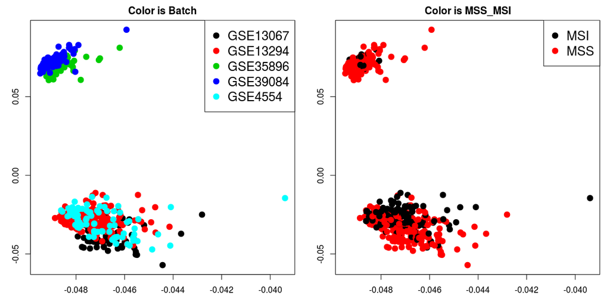

```r
 geneId.vec <- rownames(featureAttr.frm)

 ###############################

 ###############################
 # Pool the expression data
 ###############################
 PooledExpr.mtx <- do.call('cbind', lapply(KEEP_GSE.vec,
  function(SET) {
    loadObj(paste0(SET,'.arrayGeneExpr'), 'Set.arrayGeneExpr')
    Set.arrayGeneExpr$exprData[geneId.vec,]
 }))

 #dim(PooledExpr.mtx)
 #PooledExpr.mtx[1:5, 1:5]

 # Apply quantile normalization
 median.Expr.vec <- apply(apply(PooledExpr.mtx,2,sort), 1, median)
 #summary(median.Expr.vec)

 PooledNormedExpr.mtx <- apply(PooledExpr.mtx, 2, function(x)
     median.Expr.vec[rank(x)])
 rownames(PooledNormedExpr.mtx) <- rownames(PooledExpr.mtx)


 #summary(apply(PooledExpr.mtx, 2, mean))
 #summary(apply(PooledNormedExpr.mtx, 2, mean))

 ###############################
 # Pool the sample attribute data
 ###############################
 PooledSampAttr.frm <- do.call('rbind', lapply(KEEP_GSE.vec,
  function(SET) {
   #cat(SET,'\n')
    loadObj(paste0(SET,'.arrayGeneExpr'), 'Set.arrayGeneExpr')
    data.frame(GSE=rep(SET,nrow(Set.arrayGeneExpr$sampAttr)),
               Sample_Id=Set.arrayGeneExpr$sampAttr$Sample_Id,
               MS_Status=Set.arrayGeneExpr$sampAttr$MS_Status,
               row.names=rownames(Set.arrayGeneExpr$sampAttr))
  }))

 #dim(PooledSampAttr.frm)
 #PooledSampAttr.frm[1:5, ]

 # Assemble arrayGeneExpr object for pooled data and save
 GSEPool.arrayGeneExpr <-  list(exprData=NA, exprType=NA, Norm=NA,
                                  sampAttr=NA, featureAttr=NA)
 class(GSEPool.arrayGeneExpr) <- "arrayGeneExpr"
 GSEPool.arrayGeneExpr$exprData <- PooledNormedExpr.mtx
 GSEPool.arrayGeneExpr$exprType <- 'MAS5_RMA'
 GSEPool.arrayGeneExpr$Norm <- 'Quantile'
 GSEPool.arrayGeneExpr$sampAttr <- PooledSampAttr.frm
 GSEPool.arrayGeneExpr$featureAttr <- featureAttr.frm

 save(GSEPool.arrayGeneExpr, file=file.path(WRKDIR, 'Data','GSEPool.arrayGeneExpr'))

 ######################################################
 # Look for inter-set batch effects
 ######################################################
 Expt.prcomp <- prcomp(PooledNormedExpr.mtx)

 par(mfrow=c(1,2), mar=c(3,3,2,1))
 # Annotate with Batch
 plot(x=Expt.prcomp$rotation[,'PC1'],
      xlab=paste0('PC1 (', round(100*summary(Expt.prcomp)$importance[2,"PC1"],1),'%)'),
      y=Expt.prcomp$rotation[,'PC2'],
      ylab=paste0('PC2 (', round(100*summary(Expt.prcomp)$importance[2,"PC2"],1),'%)'),
      pch=19, cex=1.5, col=as.numeric(as.factor(PooledSampAttr.frm$GSE)))
 title('Color is Batch')

 legend.tbl <- table(as.factor(PooledSampAttr.frm$GSE),
                     as.numeric(as.factor(PooledSampAttr.frm$GSE)))
 legend('topright', pch=19, cex=1.5,
         legend=rownames(legend.tbl),
         col=as.numeric(colnames(legend.tbl)))

 # Annotate with MS_Status
 MSS_MSI <- as.factor(ifelse(is.element(PooledSampAttr.frm$MS_Status, c('MSS', 'No')),
          'MSS','MSI'))
 plot(x=Expt.prcomp$rotation[,'PC1'],
      xlab=paste0('PC1 (', round(100*summary(Expt.prcomp)$importance[2,"PC1"],1),'%)'),
      y=Expt.prcomp$rotation[,'PC2'],
      ylab=paste0('PC2 (', round(100*summary(Expt.prcomp)$importance[2,"PC2"],1),'%)'),
      pch=19, cex=1.5, col=as.numeric(as.factor(MSS_MSI)))
 title('Color is MSS_MSI')

 legend.tbl <- table(as.factor(MSS_MSI),
                     as.numeric(as.factor(MSS_MSI)))
 legend('topright', pch=19, cex=1.5,
         legend=rownames(legend.tbl),
         col=as.numeric(colnames(legend.tbl)))
```

## 3.5 Batch Correction

We see a definite batch effect in the PCA plot based on the pooled expression data. The clustering is along probe set reduction method, RMA vs MAS 5.0. One should reslly go back to the cel files and re-anlyze all samples using one probe set reduction method. For the sake of illustration, we will instead try to remove this effect using a batch-effect correction method.

Given that we don’t have a good set of control genes as required by the RUV method, we’ll use ’ComBat` from the [SVA](https://www.bioconductor.org/packages/release/bioc/html/sva.html) package.

Alternatively, we could keep keep the two sets of data, those siummarized using RMA and those summarized using MAS 5.0, separate, alternating using one set for model selection and fitting and the other for testing. This would provide a string test of the generalizability and robustness of the results.

```r
 suppressMessages(require(sva))

 load(file=file.path(WRKDIR, 'Data','GSEPool.arrayGeneExpr'))

 Expr.mtx <- GSEPool.arrayGeneExpr$exprData
 sampAttr.frm <- GSEPool.arrayGeneExpr$sampAttr


 # Applying theComBatfunction to adjust for known batches
 # Note: we could here use a binray batch: RMA vs MAS5.
 batch <- as.factor(sampAttr.frm$GSE)

 with(sampAttr.frm, table(GSE, MS_Status))
```

```
##           MS_Status
## GSE        High Low MSI MSS No
##   GSE13067    0   0  11  63  0
##   GSE13294    0   0  78  77  0
##   GSE35896    0   0   5  56  0
##   GSE39084   16   3   0   0 51
##   GSE4554     0   0  33  50  0
```

```r
 MSS <- as.factor(is.element(sampAttr.frm$MS_Status, c('MSS', 'No')))
 modcombat = model.matrix(~ MSS)

 combat_edata = ComBat(dat=Expr.mtx,
                       batch=batch,
                       mod=modcombat,
                       par.prior=TRUE,
                       prior.plots=FALSE)
```

```
## Found5batches
```

```
## Adjusting for1covariate(s) or covariate level(s)
```

```
## Standardizing Data across genes
```

```
## Fitting L/S model and finding priors
```

```
## Finding parametric adjustments
```

```
## Adjusting the Data
```

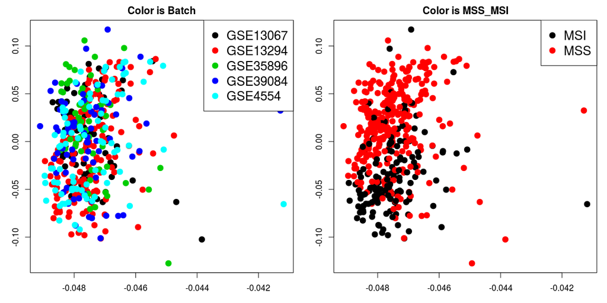

```r
 GSEPool.arrayGeneExpr$exprDataBatchAdj <- combat_edata

 save(GSEPool.arrayGeneExpr, file=file.path(WRKDIR, 'Data','GSEPool.arrayGeneExpr'))

 ######################################################
 # Look for inter-set batch effects
 ######################################################
 Expt.prcomp <- prcomp(GSEPool.arrayGeneExpr$exprDataBatchAdj)

 par(mfrow=c(1,2), mar=c(3,3,2,1))
 # Annotate with Batch
 plot(x=Expt.prcomp$rotation[,'PC1'],
      xlab=paste0('PC1 (', round(100*summary(Expt.prcomp)$importance[2,"PC1"],1),'%)'),
      y=Expt.prcomp$rotation[,'PC2'],
      ylab=paste0('PC2 (', round(100*summary(Expt.prcomp)$importance[2,"PC2"],1),'%)'),
      pch=19, cex=1.5, col=as.numeric(as.factor(sampAttr.frm$GSE)))
 title('Color is Batch')

 legend.tbl <- table(as.factor(sampAttr.frm$GSE),
                     as.numeric(as.factor(sampAttr.frm$GSE)))
 legend('topright', pch=19, cex=1.5,
         legend=rownames(legend.tbl),
         col=as.numeric(colnames(legend.tbl)))

 # Annotate with MS_Status
 MSS_MSI <- as.factor(ifelse(is.element(sampAttr.frm$MS_Status, c('MSS', 'No')),
          'MSS','MSI'))
 plot(x=Expt.prcomp$rotation[,'PC1'],
      xlab=paste0('PC1 (', round(100*summary(Expt.prcomp)$importance[2,"PC1"],1),'%)'),
      y=Expt.prcomp$rotation[,'PC2'],
      ylab=paste0('PC2 (', round(100*summary(Expt.prcomp)$importance[2,"PC2"],1),'%)'),
      pch=19, cex=1.5, col=as.numeric(as.factor(MSS_MSI)))
 title('Color is MSS_MSI')

 legend.tbl <- table(as.factor(MSS_MSI),
                     as.numeric(as.factor(MSS_MSI)))
 legend('topright', pch=19, cex=1.5,
         legend=rownames(legend.tbl),
         col=as.numeric(colnames(legend.tbl)))
```

Visual inpection of the effect of the batch correction transformation is a minimal requirement for verification. One can do a better job at quantifying the effect of batch correction, especially of the data set contains control features and control samples. See Lazar et.al. [3] for a discussion of batch effect removal assessment.

## 3.6 Separate Data Set into Train and Test Subsets

We will separate the data set into **Train** and **Test** subsets here, before any other filtering or data manipulation. In particular, since we will be interested in evaluating the effect of gene or probe set selection this selection must be made on the basis of the training subset only. This is done as a precautionary measure as gene selection based on variability is unlikely to have an effect on sample classification performance.

Take note that the expression matrices that we save here will be transposed with `genes in columns`. This is done to accumulate the data format expected by the `caret` package.

```r
 # CHANGE THIS LINE TO CLEAR CACHE
 suppressMessages(require(caret))

 # Load expression  data object
 load(file.path(WRKDIR, 'Data','GSEPool.arrayGeneExpr'))

 # Get expression data matrix
 Expr.mtx <- t(GSEPool.arrayGeneExpr$exprDataBatchAdj)

 # Use gene names where possible
 colnames(Expr.mtx) <-
 make.names(GSEPool.arrayGeneExpr$featureAttr[colnames(Expr.mtx),], unique=T)

 # Keep map
 GeneNameMap.vec <- rownames(GSEPool.arrayGeneExpr$exprDataBatchAdj)
 names(GeneNameMap.vec) <- colnames(Expr.mtx)

 #GeneNameMap.vec[1:5]

 save(GeneNameMap.vec, file=file.path(WRKDIR, 'Data', 'GeneNameMap.vec'))

 # Get sample attributes
 sampAttr.frm <- GSEPool.arrayGeneExpr$sampAttr

 DataSource.vec <- sampAttr.frm$GSE
 names(DataSource.vec) <- rownames(sampAttr.frm)

 Label.vec <- ifelse(is.element(sampAttr.frm$MS_Status, c('MSS', 'No')), 'MSS','MSI')
 names(Label.vec) <- rownames(sampAttr.frm)
 rm(GSEPool.arrayGeneExpr)

 # split Into Train and Test
 set.seed(12379)
 inTrain <- createDataPartition(y=Label.vec, p=0.75, list=F)

 Train.Expr.mtx <- Expr.mtx[inTrain,]
 Train.Label.vec <- Label.vec[inTrain]
 Train.DataSource.vec <- DataSource.vec[inTrain]


 Test.Expr.mtx <- Expr.mtx[-inTrain,]
 Test.Label.vec <- Label.vec[-inTrain]
 Test.DataSource.vec <- Label.vec[-inTrain]

 print(kable(rbind(Train=dim(Train.Expr.mtx),
             Test=dim(Test.Expr.mtx))))
```

```
##
##
## ------  ----  ------
## Train    333   54675
## Test     110   54675
## ------  ----  ------
```

```r
 print(kable(rbind(
 Trian=table(Train.Label.vec)/length(Train.Label.vec),
 Test=table(Test.Label.vec)/length(Test.Label.vec))))
```

```
##
##
##                MSI         MSS
## ------  ----------  ----------
## Trian    0.3303303   0.6696697
## Test     0.3272727   0.6727273
```

```r
 # Save these
 save(Train.Expr.mtx, file=file.path(WRKDIR, 'Data', 'Train.Expr.mtx'))
 save(Test.Expr.mtx, file=file.path(WRKDIR, 'Data', 'Test.Expr.mtx'))
 save(Train.Label.vec, file=file.path(WRKDIR, 'Data', 'Train.Label.vec'))
 save(Test.Label.vec, file=file.path(WRKDIR, 'Data', 'Test.Label.vec'))
 save(Train.DataSource.vec, file=file.path(WRKDIR, 'Data', 'Train.DataSource.vec'))
 save(Test.DataSource.vec, file=file.path(WRKDIR, 'Data', 'Test.DataSource.vec'))
```

## 3.7 Save Gene Sets

Save gene sets selected by overall variability *in training samples*. In the interest of conserving computing resources, in the analysis that follows we will use the smallest set of genes, the top 10% most variable genes.

Note that we select genes based on variability in the entire training dataset which includes data from different GEO data sets. This selection may favor the incusion of genes which differ across the different data sets due to technical reasons. An alternative selection would be to to select genes based on within data set variability. This could be implemented by filtering based on the residual variance of an anova model `Expr ~ GSE` fitted to the gene expression data.

```r
 # CHANGE THIS LINE TO CLEAR CACHE
 load(file.path(WRKDIR, 'Data', 'Train.Expr.mtx'))

 # Identify and remove low variance columns
 Train.Expr.mad.vec <- apply(Train.Expr.mtx,2,mad)
 #summary(Train.Expr.mad.vec)

 # In the interest of computing time, we'll be very conservative here
 # Come back and look improving this filter later
 Top10.cols <- which(Train.Expr.mad.vec > quantile(Train.Expr.mad.vec, prob=0.90))
 Train.Top10VarGenes.vec <- colnames(Train.Expr.mtx)[Top10.cols]
 #length(Train.Top10VarGenes.vec)

 save(Train.Top10VarGenes.vec, file=file.path(WRKDIR,'Data','Train.Top10VarGenes.vec'))

 # also save top 25 and top 50
 Top25.cols <- which(Train.Expr.mad.vec > quantile(Train.Expr.mad.vec, prob=0.75))
 Train.Top25VarGenes.vec <- colnames(Train.Expr.mtx)[Top25.cols]
 #length(Train.Top25VarGenes.vec)
 save(Train.Top25VarGenes.vec, file=file.path(WRKDIR,'Data','Train.Top25VarGenes.vec'))

 Top50.cols <- which(Train.Expr.mad.vec > quantile(Train.Expr.mad.vec, prob=0.50))
 Train.Top50VarGenes.vec <- colnames(Train.Expr.mtx)[Top50.cols]
 #length(Train.Top50VarGenes.vec)
 save(Train.Top50VarGenes.vec, file=file.path(WRKDIR,'Data','Train.Top50VarGenes.vec'))
```

# 4 Train Predictive Models

We are ready to use the Training data to evaluate various predictive models.

Set up training parameters:

```r
 suppressMessages(require(caret))

 SelGenes.CV <- paste(SelGenes, '.CV.', paste(unlist(CV), collapse='_'),sep='')

 cvControl <- trainControl(method = "repeatedcv", number=CV$Num, repeats=CV$Rep,
                           classProbs = TRUE, summaryFunction = twoClassSummary,
                           savePredictions='final')

 # Load Data
 loadObj(paste0('Train.',SelGenes,'.vec'), 'SelGenes.vec')

 load(file=file.path(WRKDIR, 'Data', 'Train.Expr.mtx'))
 Train.SelGenes.Expr.mtx <- Train.Expr.mtx[, SelGenes.vec]
 rm(Train.Expr.mtx)

 load(file=file.path(WRKDIR, 'Data', 'Train.Label.vec'))

 #dim(Train.SelGenes.Expr.mtx);length(Train.Label.vec)
```

We will use the Top10VarGenes gene set in this analysis. Model tuning and optimization will be done based on 10 repetitions of 5-fold cross-validations. This provides 10 cross-validated, or out-of-sample, predicted values for each sample in the training set. The distribution of predicted values can be examined to identify hard to predict samples. Some of these samples may potentially be mis-labelled, or may be hard to fit for other reasons. One might consider doing an analysis which exludes these samples from the training set to see what impact they have on the fits.

Some of the models which can be evaluated with `caret` include:

- stepLDA - Linear Discriminant Analysis with Stepwise Feature Selection
- stepQDA - Qaudratic Discriminant Analysis with Stepwise Feature Selection
- knn - k nearest neighbors
- pam - Nearest shrunken centroids
- rf - Random forests
- svmRadial - Support vector machines (RBF kernel)
- gbm - Boosted trees
- xgbLinear - eXtreme Gradient Boosting
- xgbTree - eXtreme Gradient Boosting
- neuralnet - neural network

Many more [models](https://topepo.github.io/caret/available-models.html) can be implemented and evaluated with `caret`, including `deep learning` methods.

## 4.1 knn - k nearest neighbors

```r
 # CHANGE THIS LINE TO CLEAR CACHE
 #################################
 set.seed(12379)
 SelGenes.knnFit.tm <- system.time(
  SelGenes.knnFit <- train(Train.SelGenes.Expr.mtx, Train.Label.vec,
               method="knn", tuneLength=10,
               trControl=cvControl, preProc=c('center','scale'))
 )
 print(SelGenes.knnFit.tm)
```

```
##     user   system  elapsed
## 1421.824    4.552  208.708
```

```r
 saveObj(paste0(SelGenes.CV, '.knnFit'), 'SelGenes.knnFit')
```

```
## k-Nearest Neighbors
##
##  333 samples
## 5468 predictors
##    2 classes: 'MSI', 'MSS'
##
## Pre-processing: centered (5468), scaled (5468)
## Resampling: Cross-Validated (5 fold, repeated 10 times)
## Summary of sample sizes: 267, 267, 266, 266, 266, 266, ...
## Resampling results across tuning parameters:
##
##   k   ROC        Sens       Spec
##    5  0.8510721  0.5990909  0.9390303
##    7  0.8582665  0.5672727  0.9609899
##    9  0.8590574  0.5090909  0.9703838
##   11  0.8671508  0.4845455  0.9757677
##   13  0.8657573  0.4772727  0.9811414
##   15  0.8655342  0.4618182  0.9829394
##   17  0.8702663  0.4590909  0.9824747
##   19  0.8812548  0.4381818  0.9820202
##   21  0.8910034  0.4345455  0.9824949
##   23  0.8940255  0.4300000  0.9851919
##
## ROC was used to select the optimal model using  the largest value.
## The final value used for the model was k = 23.
```

```r
 set.seed(12379)
 SelGenes.pamFit.tm <- system.time(
 SelGenes.pamFit <- train(Train.SelGenes.Expr.mtx, Train.Label.vec,
               method="pam",
               trControl=cvControl, preProc=c('center','scale'))
 )
```

```
## 123456789101112131415161718192021222324252627282930
```

```
## 1
```

```r
 print(SelGenes.pamFit.tm)
```

```
##    user  system elapsed
##  90.252  46.248  23.889
```

```r
 saveObj(paste0(SelGenes.CV, '.pamFit'), 'SelGenes.pamFit')
```

```
## Nearest Shrunken Centroids
##
##  333 samples
## 5468 predictors
##    2 classes: 'MSI', 'MSS'
##
## Pre-processing: centered (5468), scaled (5468)
## Resampling: Cross-Validated (5 fold, repeated 10 times)
## Summary of sample sizes: 267, 267, 266, 266, 266, 266, ...
## Resampling results across tuning parameters:
##
##   threshold  ROC        Sens       Spec
##   0.2821492  0.8908411  0.8281818  0.8615758
##   4.0911639  0.9518838  0.8390909  0.9879293
##   7.9001785  0.5000000  0.0000000  1.0000000
##
## ROC was used to select the optimal model using  the largest value.
## The final value used for the model was threshold = 4.091164.
```

## 4.2 rf - Random forests

```r
 set.seed(12379)
 SelGenes.rfFit.tm <- system.time(
 SelGenes.rfFit <- train(Train.SelGenes.Expr.mtx, Train.Label.vec,
               method="rf",
               trControl=cvControl, preProc=c('center','scale'))
 )
 print(SelGenes.rfFit.tm)
```

```
##     user   system  elapsed
## 8094.320   11.036 1228.414
```

```r
 saveObj(paste0(SelGenes.CV, '.rfFit'), 'SelGenes.rfFit')
```

```
## Random Forest
##
##  333 samples
## 5468 predictors
##    2 classes: 'MSI', 'MSS'
##
## Pre-processing: centered (5468), scaled (5468)
## Resampling: Cross-Validated (5 fold, repeated 10 times)
## Summary of sample sizes: 267, 267, 266, 266, 266, 266, ...
## Resampling results across tuning parameters:
##
##   mtry  ROC        Sens       Spec
##      2  0.8913212  0.2445455  0.9977374
##    104  0.9416210  0.7954545  0.9762626
##   5468  0.9476132  0.8090909  0.9700505
##
## ROC was used to select the optimal model using  the largest value.
## The final value used for the model was mtry = 5468.
```

## 4.3 svmRadial - Support vector machines (RBF kernel)

```r
 set.seed(12379)
 SelGenes.svmRadialFit.tm <- system.time(
 SelGenes.svmRadialFit <- train(Train.SelGenes.Expr.mtx, Train.Label.vec,
               method="svmRadial",
               trControl=cvControl, preProc=c('center','scale'))
 )
 print(SelGenes.svmRadialFit.tm)
```

```
##     user   system  elapsed
## 2189.472  242.988  193.382
```

```r
 saveObj(paste0(SelGenes.CV, '.svmRadialFit'), 'SelGenes.svmRadialFit')
```

```
## Support Vector Machines with Radial Basis Function Kernel
##
##  333 samples
## 5468 predictors
##    2 classes: 'MSI', 'MSS'
##
## Pre-processing: centered (5468), scaled (5468)
## Resampling: Cross-Validated (5 fold, repeated 10 times)
## Summary of sample sizes: 267, 267, 266, 266, 266, 266, ...
## Resampling results across tuning parameters:
##
##   C     ROC        Sens       Spec
##   0.25  0.9001827  0.8427273  0.8615657
##   0.50  0.9003875  0.8390909  0.8624545
##   1.00  0.9072332  0.8027273  0.9327778
##
## Tuning parameter 'sigma' was held constant at a value of 9.347479e-05
## ROC was used to select the optimal model using  the largest value.
## The final values used for the model were sigma = 9.347479e-05 and C = 1.
```

## 4.4 gbm - Boosted trees

```r
 set.seed(12379)
 SelGenes.gbmFit.tm <- system.time(
 SelGenes.gbmFit <- train(Train.SelGenes.Expr.mtx, Train.Label.vec,
               method="gbm", verbose=F,
               trControl=cvControl, preProc=c('center','scale'))
 )
 print(SelGenes.gbmFit.tm)
```

```
##     user   system  elapsed
## 1907.132   41.024  261.356
```

```r
 saveObj(paste0(SelGenes.CV, '.gbmFit'), 'SelGenes.gbmFit')
```

```
## Stochastic Gradient Boosting
##
##  333 samples
## 5468 predictors
##    2 classes: 'MSI', 'MSS'
##
## Pre-processing: centered (5468), scaled (5468)
## Resampling: Cross-Validated (5 fold, repeated 10 times)
## Summary of sample sizes: 267, 267, 266, 266, 266, 266, ...
## Resampling results across tuning parameters:
##
##   interaction.depth  n.trees  ROC        Sens       Spec
##   1                   50      0.9441860  0.8181818  0.9852323
##   1                  100      0.9387222  0.8254545  0.9829798
##   1                  150      0.9362681  0.8309091  0.9843131
##   2                   50      0.9454798  0.8300000  0.9816566
##   2                  100      0.9443540  0.8300000  0.9834343
##   2                  150      0.9409959  0.8300000  0.9820909
##   3                   50      0.9423737  0.8336364  0.9816465
##   3                  100      0.9403613  0.8218182  0.9838788
##   3                  150      0.9405450  0.8263636  0.9838687
##
## Tuning parameter 'shrinkage' was held constant at a value of 0.1
##
## Tuning parameter 'n.minobsinnode' was held constant at a value of 10
## ROC was used to select the optimal model using  the largest value.
## The final values used for the model were n.trees = 50, interaction.depth
##  = 2, shrinkage = 0.1 and n.minobsinnode = 10.
```

## 4.5 xgbLinear - eXtreme Gradient Boosting

```r
 set.seed(12379)
 SelGenes.xgbLinearFit.tm <- system.time(
 SelGenes.xgbLinearFit <- train(Train.SelGenes.Expr.mtx, Train.Label.vec,
               method="xgbLinear", verbose=F,
               trControl=cvControl, preProc=c('center','scale'))
 )
 print(SelGenes.xgbLinearFit.tm)
```

```
##      user    system   elapsed
## 36482.840    57.768  5198.825
```

```r
 saveObj(paste0(SelGenes.CV, '.xgbLinearFit'), 'SelGenes.xgbLinearFit')
```

```
## eXtreme Gradient Boosting
##
##  333 samples
## 5468 predictors
##    2 classes: 'MSI', 'MSS'
##
## Pre-processing: centered (5468), scaled (5468)
## Resampling: Cross-Validated (5 fold, repeated 10 times)
## Summary of sample sizes: 267, 267, 266, 266, 266, 266, ...
## Resampling results across tuning parameters:
##
##   lambda  alpha  nrounds  ROC        Sens       Spec
##   0e+00   0e+00   50      0.9335840  0.8300000  0.9673232
##   0e+00   0e+00  100      0.9335840  0.8300000  0.9673232
##   0e+00   0e+00  150      0.9335840  0.8300000  0.9673232
##   0e+00   1e-04   50      0.9337456  0.8254545  0.9686667
##   0e+00   1e-04  100      0.9337456  0.8254545  0.9686667
##   0e+00   1e-04  150      0.9337456  0.8254545  0.9686667
##   0e+00   1e-01   50      0.9344334  0.8300000  0.9691313
##   0e+00   1e-01  100      0.9344334  0.8300000  0.9691313
##   0e+00   1e-01  150      0.9344334  0.8300000  0.9691313
##   1e-04   0e+00   50      0.9340891  0.8263636  0.9677576
##   1e-04   0e+00  100      0.9340891  0.8263636  0.9677576
##   1e-04   0e+00  150      0.9340891  0.8263636  0.9677576
##   1e-04   1e-04   50      0.9332287  0.8254545  0.9682222
##   1e-04   1e-04  100      0.9332287  0.8254545  0.9682222
##   1e-04   1e-04  150      0.9332287  0.8254545  0.9682222
##   1e-04   1e-01   50      0.9341841  0.8309091  0.9686869
##   1e-04   1e-01  100      0.9341841  0.8309091  0.9686869
##   1e-04   1e-01  150      0.9341841  0.8309091  0.9686869
##   1e-01   0e+00   50      0.9339210  0.8254545  0.9691313
##   1e-01   0e+00  100      0.9339210  0.8254545  0.9691313
##   1e-01   0e+00  150      0.9339210  0.8254545  0.9691313
##   1e-01   1e-04   50      0.9339839  0.8263636  0.9700202
##   1e-01   1e-04  100      0.9339839  0.8263636  0.9700202
##   1e-01   1e-04  150      0.9339839  0.8263636  0.9700202
##   1e-01   1e-01   50      0.9319389  0.8363636  0.9677677
##   1e-01   1e-01  100      0.9319389  0.8363636  0.9677677
##   1e-01   1e-01  150      0.9319389  0.8363636  0.9677677
##
## Tuning parameter 'eta' was held constant at a value of 0.3
## ROC was used to select the optimal model using  the largest value.
## The final values used for the model were nrounds = 50, lambda = 0, alpha
##  = 0.1 and eta = 0.3.
```

# 5 Compare Predictive Models

Here we compare predictive models in terms of:

- Processing time
- Prediction accuracy and ROC on train samples
- Prediction accuracy and ROC on train `out-of-sample`
- Prediction accuracy and ROC on test samples
- Direct comparison of variable importance

## 5.1 Load Models

```r
 # Load Train and Test Data
 load(file=file.path(WRKDIR, 'Data', 'Train.Expr.mtx'))
 load(file=file.path(WRKDIR, 'Data', 'Test.Expr.mtx'))
 load(file=file.path(WRKDIR, 'Data', 'Train.Label.vec'))
 load(file=file.path(WRKDIR, 'Data', 'Test.Label.vec'))

 CLASS1 <- as.character(sort(unique(Train.Label.vec))[1])
 CLASS2 <- as.character(sort(unique(Train.Label.vec))[2])

 # Load models
 ModelFit.vec <- list.files(file.path(WRKDIR, 'Data'), 'Fit$')

 # Stratify according to batch effect correction
 FitSetCV.vec <- sapply(strsplit(ModelFit.vec, split='\\.'),
            function(x) paste(x[1:3], collapse='.'))

 ModelFit.lst <- split(sapply(strsplit(ModelFit.vec, split='\\.'), function(x) rev(x)[1]),
                       FitSetCV.vec)

 # Get Model.col for plotting (only have one FitSetCV values here.  could have many)
 Model.col <- as.numeric(as.factor(ModelFit.lst[[1]]))
 names(Model.col) <- ModelFit.lst[[1]]

 cat("Found", length(ModelFit.vec), 'models:\n')
```

```
## Found 6 models:
```

```r
 print(ModelFit.lst)
```

```
## $Top10VarGenes.CV.5_10
## [1] "gbmFit"       "knnFit"       "pamFit"       "rfFit"
## [5] "svmRadialFit" "xgbLinearFit"
```

```r
 # Load Models for single set (we cd have more than one set in FitSetCV.vec)
 SET <- names(ModelFit.lst)[1]
 Set.ModelFit.lst <- lapply(ModelFit.lst[[SET]],
  function(MF) {
   loadObj(paste(SET, MF, sep='.'), 'ModelFit')
   ModelFit})
 names(Set.ModelFit.lst) <- ModelFit.lst[[SET]]
```

## 5.2 Compare Times

```r
  Set.ModelTimes.frm <- do.call('rbind', lapply(Set.ModelFit.lst,
  function(LL) c(all=LL$times$everything)))###, final=LL$times$final)))

  print(kable(t(Set.ModelTimes.frm), digits=2))
```

```
##
##
##                    gbmFit    knnFit   pamFit     rfFit   svmRadialFit   xgbLinearFit
## ---------------  --------  --------  -------  --------  -------------  -------------
## all.user.self        6.14      1.96     5.20     53.31           9.80          10.78
## all.sys.self         0.14      0.20     6.99      0.09           2.54           0.19
## all.elapsed        261.36    208.71    23.89   1228.05         193.38        5198.48
## all.user.child    1900.99   1419.86    85.05   8040.64        2179.67       36471.72
## all.sys.child       40.88      4.35    39.26     10.95         240.45          57.58
```

## 5.3 Compare Prediction Accuracy

### 5.3.1 Train Data Accuracy

```r
 suppressMessages(require(caret))

 # Train - these are fitting errors
 Set.Train.Pred.lst <- suppressMessages(predict(Set.ModelFit.lst))
          #, newdata=Train.SelGenes.Expr.mtx))

 Set.Train.TruthTable.frm <- do.call('rbind', lapply(Set.Train.Pred.lst,
 function(PRED) {
   truth.vec <- as.vector(table(PRED, Train.Label.vec))#/length(Train.Label.vec)
   # ASSUMING MSI is FIRST LABEL of CLASS
   names(truth.vec) <- c('TN', 'FP', 'FN', 'TP')
   truth.vec}))

 print(
  kable(data.frame(cbind(Set.Train.TruthTable.frm,
                  Set.Train.TruthTable.frm/length(Train.Label.vec))),
    digits=2, align='c')
  )
```

```
##
##
##                 TN     FP    FN    TP     TN.1    FP.1    FN.1    TP.1
## -------------  -----  ----  ----  -----  ------  ------  ------  ------
## gbmFit          105    5     1     222    0.32    0.02    0.00    0.67
## knnFit          51     59    3     220    0.15    0.18    0.01    0.66
## pamFit          95     15    7     216    0.29    0.05    0.02    0.65
## rfFit           110    0     0     223    0.33    0.00    0.00    0.67
## svmRadialFit    102    8     3     220    0.31    0.02    0.01    0.66
## xgbLinearFit    110    0     0     223    0.33    0.00    0.00    0.67
```

### 5.3.2 Out of Sample Train Data Accuracy

```r
  Set.ModelFit.osPred.mtx.lst <- lapply(Set.ModelFit.lst,
 function(MF) {
   MF.pred.mtx <- MF$pred
   Rep.vec <- sapply(strsplit(MF$pred$Resample, split='\\.'),'[', 2)
   rowIndex.vec <- sort(unique(MF$pred$rowIndex))
   Pred.mtx <- do.call('cbind', lapply(split(MF$pred, Rep.vec),
   function(RepMFpred.frm)
      as.character(RepMFpred.frm[match(rowIndex.vec, RepMFpred.frm$rowIndex),'pred'])))
   Pred.mtx})

 # Use mode over reps as prediction
 ############################################
 Set.ModelFit.osPred.vec.lst <- lapply(Set.ModelFit.osPred.mtx.lst,
 function(PRED.mtx) apply(PRED.mtx,1,function(Pred.vec)
 names(table(Pred.vec))[which.max(table(Pred.vec))]))

 Set.Train.osPredMode.TruthTable.frm <- do.call('rbind', lapply(Set.ModelFit.osPred.vec.lst,
 function(PRED) {
   truth.vec <- as.vector(table(PRED, Train.Label.vec))#/length(Train.Label.vec)
   # ASSUMING MSI is FIRST LABEL of CLASS
   names(truth.vec) <- c('TN', 'FP', 'FN', 'TP')
   truth.vec}))

 print(
 kable(data.frame(cbind(Set.Train.osPredMode.TruthTable.frm,
                  Set.Train.osPredMode.TruthTable.frm/length(Train.Label.vec))),
    digits=2, align='c')
 )
```

```
##
##
##                 TN    FP    FN    TP     TN.1    FP.1    FN.1    TP.1
## -------------  ----  ----  ----  -----  ------  ------  ------  ------
## gbmFit          93    17    3     220    0.28    0.05    0.01    0.66
## knnFit          51    59    3     220    0.15    0.18    0.01    0.66
## pamFit          92    18    2     221    0.28    0.05    0.01    0.66
## rfFit           93    17    6     217    0.28    0.05    0.02    0.65
## svmRadialFit    89    21    14    209    0.27    0.06    0.04    0.63
## xgbLinearFit    94    16    7     216    0.28    0.05    0.02    0.65
```

```r
 ############################################
 # alternatively, can look at the osPred by rep
 # and use mean for error rates
 ############################################
 Set.Train.osPredMean.TruthTable.frm <- do.call('rbind', lapply(Set.ModelFit.osPred.mtx.lst,
  function(PRED.mtx) {
   TruthTable.mtx <- do.call('rbind', lapply(1:ncol(PRED.mtx),
   function(CC) as.vector(table(PRED.mtx[,CC], Train.Label.vec)/length(Train.Label.vec))))
   apply(TruthTable.mtx,2,mean)}))
  colnames(Set.Train.osPredMean.TruthTable.frm) <- c('TN', 'FP', 'FN', 'TP')

  print(
    kable(data.frame(Set.Train.osPredMean.TruthTable.frm),
       digits=2, align='c')
  )
```

```
##
##
##                  TN      FP      FN      TP
## -------------  ------  ------  ------  ------
## gbmFit          0.27    0.06    0.01    0.66
## knnFit          0.14    0.19    0.01    0.66
## pamFit          0.28    0.05    0.01    0.66
## rfFit           0.27    0.06    0.02    0.65
## svmRadialFit    0.27    0.07    0.05    0.62
## xgbLinearFit    0.27    0.06    0.02    0.65
```

### 5.3.3 Test Data Accuracy

```r
 suppressMessages(require(caret))

 # Test - these are fitting errors
 Set.Test.Pred.lst <- lapply(Set.ModelFit.lst,
          function(MF) predict(MF, newdata=Test.Expr.mtx))
 Set.Test.TruthTable.frm <- do.call('rbind', lapply(Set.Test.Pred.lst,
 function(PRED) {
   truth.vec <- as.vector(table(PRED, Test.Label.vec))#/length(Test.Label.vec)
   # ASSUMING MSI is FIRST LABEL of CLASS
   names(truth.vec) <- c('TN', 'FP', 'FN', 'TP')
   truth.vec}))

 print(kable(data.frame(cbind(Set.Test.TruthTable.frm,
                  Set.Test.TruthTable.frm/length(Test.Label.vec))),
    digits=2, align='c'))
```

```
##
##
##                 TN    FP    FN    TP    TN.1    FP.1    FN.1    TP.1
## -------------  ----  ----  ----  ----  ------  ------  ------  ------
## gbmFit          32    4     1     73    0.29    0.04    0.01    0.66
## knnFit          16    20    1     73    0.15    0.18    0.01    0.66
## pamFit          33    3     3     71    0.30    0.03    0.03    0.65
## rfFit           31    5     3     71    0.28    0.05    0.03    0.65
## svmRadialFit    0     0     0     0     0.00    0.00    0.00    0.00
## xgbLinearFit    32    4     2     72    0.29    0.04    0.02    0.65
```

## 5.4 Compare Models in Terms of ROC

### 5.4.1 Training Data ROC

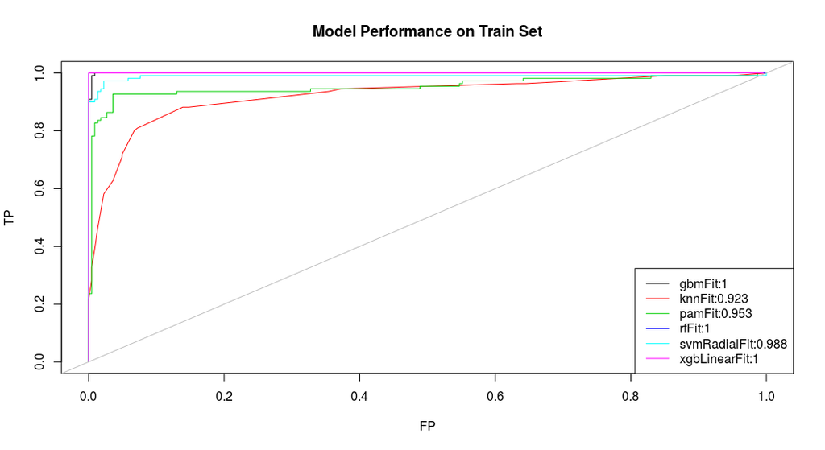

```r
 # CHANGE THIS LINE TO CLEAR CACHE
 suppressMessages(require(pROC))

 ################################
 # Train
 ################################
 # Get predicted probabilities
 Set.Train.Prob.lst <- suppressMessages(predict(Set.ModelFit.lst, type='prob'))
 Set.Train.ProbClass1.mtx <- do.call('cbind',
    lapply(Set.Train.Prob.lst, function(x) x[,CLASS1]))

 rownames(Set.Train.ProbClass1.mtx) <- names(Train.Label.vec)

 # ROC
 Set.Train.roc.mtx.lst <- lapply(colnames(Set.Train.ProbClass1.mtx), function(MM)
    do.call('rbind', lapply(rev(sort(unique(Set.Train.ProbClass1.mtx))),
     function(TS) {
        TP <- sum(Set.Train.ProbClass1.mtx[,MM][Train.Label.vec==CLASS1] > TS, na.rm=T)
        FP <- sum(Set.Train.ProbClass1.mtx[,MM][Train.Label.vec==CLASS2] > TS, na.rm=T)
        c(TS=TS, TP=TP, FP=FP)}))
   )
 names(Set.Train.roc.mtx.lst) <- colnames(Set.Train.ProbClass1.mtx)
 # Get auc
 Set.Train.auc.vec <- sapply(1:ncol(Set.Train.ProbClass1.mtx), function(CC)
   auc(Train.Label.vec, Set.Train.ProbClass1.mtx[,CC]))
 names(Set.Train.auc.vec) <- colnames(Set.Train.ProbClass1.mtx)


 plot(x=range(do.call('c', lapply(Set.Train.roc.mtx.lst,
                function(LL) LL[,'FP'])))/sum(Train.Label.vec==CLASS2),
      y=range(do.call('c', lapply(Set.Train.roc.mtx.lst,
                function(LL) LL[,'TP'])))/sum(Train.Label.vec==CLASS1),
      xlab='FP', ylab='TP', type='n')

 for(II in 1:length(Set.Train.roc.mtx.lst))
 lines(x=Set.Train.roc.mtx.lst[[II]][,'FP']/sum(Train.Label.vec==CLASS2),
       y=Set.Train.roc.mtx.lst[[II]][,'TP']/sum(Train.Label.vec==CLASS1),
       col=Model.col[names(Set.Train.roc.mtx.lst)[II]])
 abline(0,1, col='grey')
 legend('bottomright',
        legend=paste(names(Set.Train.roc.mtx.lst), ':',
          round(Set.Train.auc.vec[names(Set.Train.roc.mtx.lst)],3),sep=''),
        col=Model.col[names(Set.Train.roc.mtx.lst)],
        lty=1)
 title('Model Performance on Train Set')
```

### 5.4.2 Out-of-sample Train: Average over Repeats

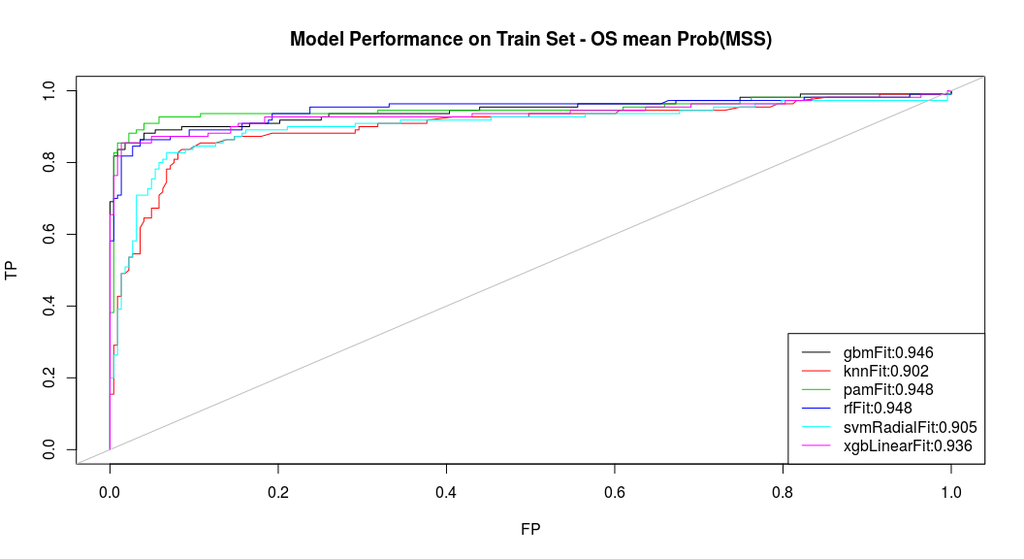

```r
 suppressMessages(require(pROC))
 # Get predicted probabilities
 Set.ModelFit.osProbClass1.mtx.lst <- lapply(Set.ModelFit.lst,
 function(MF) {
   MF.pred.mtx <- MF$pred
   Rep.vec <- sapply(strsplit(MF$pred$Resample, split='\\.'),'[', 2)
   rowIndex.vec <- sort(unique(MF$pred$rowIndex))
   ProbClass1.mtx <- do.call('cbind', lapply(split(MF$pred, Rep.vec),
   function(RepMFpred.frm)
      RepMFpred.frm[match(rowIndex.vec, RepMFpred.frm$rowIndex),CLASS1]))
   ProbClass1.mtx})


 #################################
 # Use average osProb
 #################################
 Set.Train.mean_osProbClass1.mtx <- do.call('cbind', lapply(Set.ModelFit.osProbClass1.mtx.lst,
  function(osProbClass1.mtx) apply(osProbClass1.mtx,1,mean)))
 rownames(Set.Train.mean_osProbClass1.mtx) <- names(Train.Label.vec)

 # ROC
  Set.Train.mean_osProbClass1.roc.mtx.lst <-
  lapply(colnames(Set.Train.mean_osProbClass1.mtx), function(MM)
   do.call('rbind', lapply(rev(sort(unique(Set.Train.mean_osProbClass1.mtx))),
    function(TS) {
     TP <- sum(Set.Train.mean_osProbClass1.mtx[,MM][Train.Label.vec==CLASS1] > TS, na.rm=T)
     FP <- sum(Set.Train.mean_osProbClass1.mtx[,MM][Train.Label.vec==CLASS2] > TS, na.rm=T)
        c(TS=TS, TP=TP, FP=FP)}))
   )
 names(Set.Train.mean_osProbClass1.roc.mtx.lst) <- colnames(Set.Train.mean_osProbClass1.mtx)

 # Get auc
 Set.Train.mean_osProbClass1.auc.vec <- sapply(1:ncol(Set.Train.mean_osProbClass1.mtx), function(CC)
   auc(Train.Label.vec, Set.Train.mean_osProbClass1.mtx[,CC]))
 names(Set.Train.mean_osProbClass1.auc.vec) <- colnames(Set.Train.mean_osProbClass1.mtx)


 plot(x=range(do.call('c', lapply(Set.Train.mean_osProbClass1.roc.mtx.lst,
                function(LL) LL[,'FP'])))/sum(Train.Label.vec==CLASS2),
      y=range(do.call('c', lapply(Set.Train.mean_osProbClass1.roc.mtx.lst,
                function(LL) LL[,'TP'])))/sum(Train.Label.vec==CLASS1),
      xlab='FP', ylab='TP', type='n')

 for(II in 1:length(Set.Train.mean_osProbClass1.roc.mtx.lst))
 lines(x=Set.Train.mean_osProbClass1.roc.mtx.lst[[II]][,'FP']/sum(Train.Label.vec==CLASS2),
       y=Set.Train.mean_osProbClass1.roc.mtx.lst[[II]][,'TP']/sum(Train.Label.vec==CLASS1),
       col=Model.col[names(Set.Train.roc.mtx.lst)[II]])
 abline(0,1, col='grey')
 legend('bottomright',
        legend=paste(names(Set.Train.mean_osProbClass1.auc.vec), ':',
          round(Set.Train.mean_osProbClass1.auc.vec,3),sep=''),
        col=Model.col[names(Set.Train.mean_osProbClass1.auc.vec)], lty=1)
 title('Model Performance on Train Set - OS mean Prob(MSS)')
```

### 5.4.3 Out-of-sample Set.Train: Individual Repeats

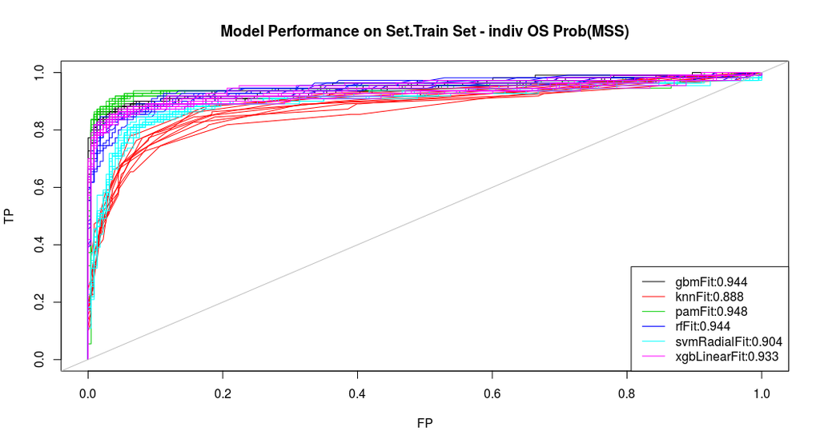

```r
 suppressMessages(require(pROC))

 #################################
 # Replot ROC keep individual rep osProbClass1
 #################################
 Set.Train.indiv_osProbClass1.mtx <- do.call('cbind', lapply(names(Set.ModelFit.osProbClass1.mtx.lst),
  function(MODEL) {
   osProbClass1.mtx <- Set.ModelFit.osProbClass1.mtx.lst[[MODEL]]
   colnames(osProbClass1.mtx) <- paste(MODEL, colnames(osProbClass1.mtx),sep='.')
   osProbClass1.mtx}))
 rownames(Set.Train.indiv_osProbClass1.mtx) <- names(Train.Label.vec)

 # ROC
 Set.Train.indiv_osProbClass1.roc.mtx.lst <- lapply(colnames(Set.Train.indiv_osProbClass1.mtx), function(MM)
    do.call('rbind', lapply(rev(sort(unique(Set.Train.indiv_osProbClass1.mtx))),
     function(TS) {
        TP <- sum(Set.Train.indiv_osProbClass1.mtx[,MM][Train.Label.vec==CLASS1] > TS, na.rm=T)
        FP <- sum(Set.Train.indiv_osProbClass1.mtx[,MM][Train.Label.vec==CLASS2] > TS, na.rm=T)
        c(TS=TS, TP=TP, FP=FP)}))
   )
 names(Set.Train.indiv_osProbClass1.roc.mtx.lst) <- colnames(Set.Train.indiv_osProbClass1.mtx)


 # Get auc
 Set.Train.indiv_osProbClass1.auc.vec <- sapply(1:ncol(Set.Train.indiv_osProbClass1.mtx), function(CC)
   auc(Train.Label.vec, Set.Train.indiv_osProbClass1.mtx[,CC]))
 names(Set.Train.indiv_osProbClass1.auc.vec) <- colnames(Set.Train.indiv_osProbClass1.mtx)

 Set.Train.mean_indiv_osProbClass1.auc.vec <- sapply(split(Set.Train.indiv_osProbClass1.auc.vec,
   sapply(strsplit(names(Set.Train.indiv_osProbClass1.auc.vec), split='\\.'),'[',1)),
   mean)

 plot(x=range(do.call('c', lapply(Set.Train.indiv_osProbClass1.roc.mtx.lst,
                function(LL) LL[,'FP'])))/sum(Train.Label.vec==CLASS2),
      y=range(do.call('c', lapply(Set.Train.indiv_osProbClass1.roc.mtx.lst,
                function(LL) LL[,'TP'])))/sum(Train.Label.vec==CLASS1),
      xlab='FP', ylab='TP', type='n')

 for(II in 1:length(Set.Train.indiv_osProbClass1.roc.mtx.lst))
 lines(x=Set.Train.indiv_osProbClass1.roc.mtx.lst[[II]][,'FP']/sum(Train.Label.vec==CLASS2),
       y=Set.Train.indiv_osProbClass1.roc.mtx.lst[[II]][,'TP']/sum(Train.Label.vec==CLASS1),
       col=Model.col[sapply(strsplit(names(Set.Train.indiv_osProbClass1.roc.mtx.lst),'\\.'),'[',1)[II]])
 abline(0,1, col='grey')
 legend('bottomright',
        legend=paste(names(Set.Train.mean_indiv_osProbClass1.auc.vec), ':',
        round(Set.Train.mean_indiv_osProbClass1.auc.vec,3),sep=''),
       col=Model.col[names(Set.Train.mean_indiv_osProbClass1.auc.vec)],lty=1)
 title('Model Performance on Set.Train Set - indiv OS Prob(MSS)')
```

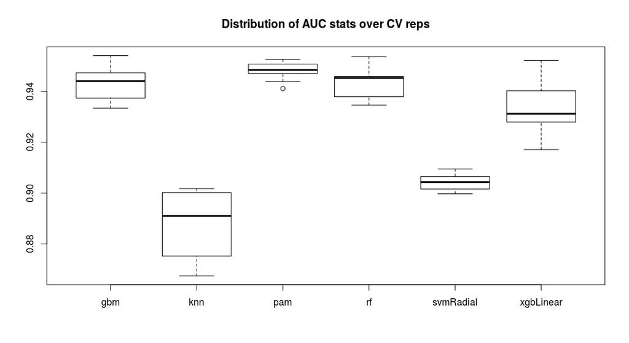

```r
 # Boxplot individual aucs
 boxplot(split(Set.Train.indiv_osProbClass1.auc.vec,
   sub('Fit','', sapply(strsplit(names(Set.Train.indiv_osProbClass1.auc.vec), split='\\.'),'[',1))))
 title('Distribution of AUC stats over CV reps')
```

```r
  Set.Train.indiv_osProbClass1.auc.mtx <- do.call('rbind',
  lapply(split(Set.Train.indiv_osProbClass1.auc.vec,
   sapply(strsplit(names(Set.Train.indiv_osProbClass1.auc.vec), split='\\.'),'[',1)),
   function(x) {Res=x; names(Res)<- sapply(strsplit(names(Res),split='\\.'),'[',2);Res}))

 # This is redundant
 #kable(data.frame(Set.Train.indiv_osProbClass1.auc.mtx,
                  #mean_os=Set.Train.mean_osProbClass1.auc.vec),
                  ##Test = Test.auc.vec),
    #digits=2, format='html',align='c')
```

### 5.4.4 Compare Predicted Probabilities

With the repeated CV fitting set-up, we can examine the distribution of out-of-sample predictions. This is useful to both characterize the mode of errors occuring in a given model - are the errors due to bias or variability? - as well as chracterizing samples - some samples may be mis-labelled or hard to classify correctly.

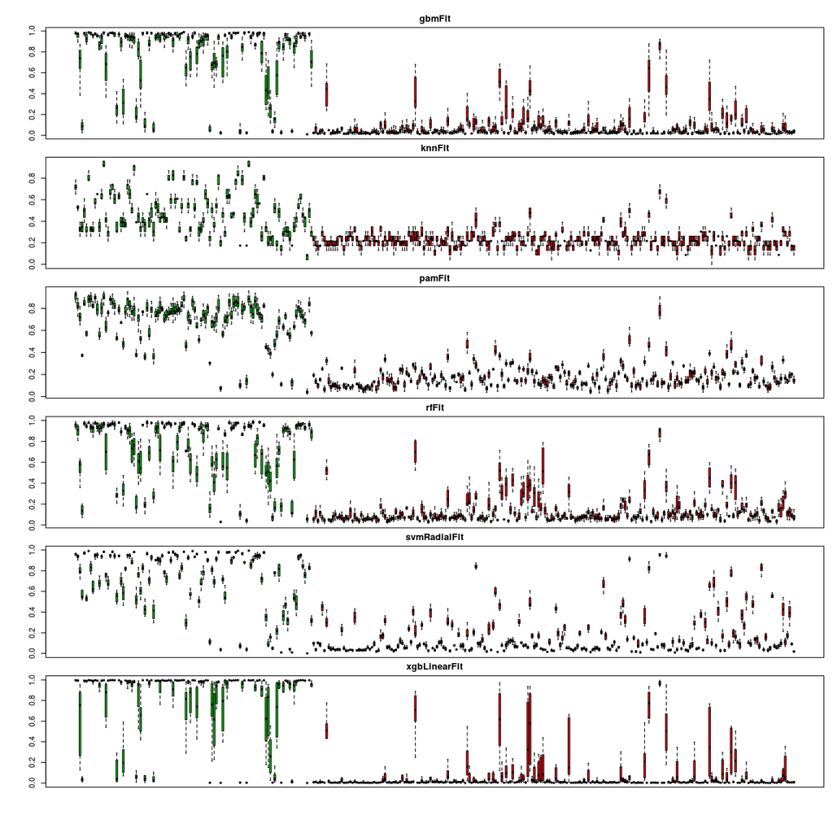

```r
  if(sum(rownames(Set.Train.indiv_osProbClass1.mtx) !=
         names(Train.Label.vec)))
  stop("Sample ordering problem.")

  # Reorder by Outcome
  row.o <- order(Train.Label.vec, names(Train.Label.vec))

  Col.Models.vec <- sapply(strsplit(colnames(Set.Train.indiv_osProbClass1.mtx), split='\\.'),'[',1)

  par(mfrow=c(length(unique(Col.Models.vec)),1), mar=c(0,5,2,1), oma=c(5,0,1,0))

  for(MOD in unique(Col.Models.vec)) {
   Mod.cols <- which(Col.Models.vec==MOD)

   box.out <-
   boxplot(t(Set.Train.indiv_osProbClass1.mtx[row.o,Mod.cols]),
           col=ifelse(Train.Label.vec[row.o]==CLASS1,3,2),
           xaxt='n', outline=F)
   title(MOD)
  }
```

## 5.5 Look at Variable Importance

The `caret` package provides methods to extract variable importance through the varImp function. Here we will extract these assessments for each model and compare with genes which have been identified as associated with MSS status in other studies:

- BANERJEA [19]
- CROCE [20]
- JORISSEN [21]
- KOINUMA [22]
- KRUHOFFER [23]
- MORI [24]

```r
  MSSMSI.GeneSets.frm <- read.table(file=file.path(EXT_DATA, "ColonCancerGeneSets.tab"),
   header=T, sep='\t')

  GeneSets.lst <- split(MSSMSI.GeneSets.frm$GeneSymbol, toupper(MSSMSI.GeneSets.frm$ListName))
  GeneSets.lst <- GeneSets.lst[c('BANERJEA','CROCE','JORISSEN', 'KOINUMA', 'KRUHOFFER','MORI')]
```

```r
 suppressMessages(require(caret))

 # Load gene to probe set map
 load(file=file.path(WRKDIR, 'Data', 'GeneNameMap.vec'))

 # Will also need the inverted map
 GeneNameMap2.vec <- names(GeneNameMap.vec)
 names(GeneNameMap2.vec) <- GeneNameMap.vec

  Set.ModelFit.Top20.lst <- lapply(setdiff(names(Set.ModelFit.lst),
                                   c("knnFit","sddaLDAFit","sddaQDAFit")),
  function(MOD) {
    #cat(MOD,'\n')
    FIT <- Set.ModelFit.lst[[MOD]]

    if(is.element(CLASS1, colnames(varImp(FIT)$imp)))
    impVar.vec <- varImp(FIT)$imp[,CLASS1] else
    impVar.vec <- varImp(FIT)$imp$Overall

    top20.ndx <- rev(order(impVar.vec))[1:20]
    varImp.vec <- impVar.vec[top20.ndx]
    names(varImp.vec) <- rownames(varImp(FIT)$imp)[top20.ndx]
    varImp.vec
    })
  names(Set.ModelFit.Top20.lst) <- setdiff(names(Set.ModelFit.lst),
                                   c("knnFit","sddaLDAFit","sddaQDAFit"))

  Top20.Name.vec <- unique(do.call('c', lapply(Set.ModelFit.Top20.lst, function(VV) names(VV))))

  Top20.ProbeId.vec <- GeneNameMap.vec[Top20.Name.vec]

  # Put together in a matrix
  Top20.varImp.mtx <- do.call('cbind', lapply(Set.ModelFit.Top20.lst,
   function(LL) LL[Top20.Name.vec]))
  rownames(Top20.varImp.mtx) <- GeneNameMap.vec[Top20.Name.vec]
  Top20.varImp.mtx[is.na(Top20.varImp.mtx)] <- 0

  # Reoder by ovrall importance
  varImp.med.vec <- apply(Top20.varImp.mtx,1,median)
  Top20.varImp.mtx <- Top20.varImp.mtx[rev(order(varImp.med.vec)),]


  Top20.varImp.frm <- data.frame(PROBEID=rownames(Top20.varImp.mtx),
                                 Gene=GeneNameMap2.vec[rownames(Top20.varImp.mtx)],
                                 round(Top20.varImp.mtx))
  names(Top20.varImp.frm) <- sub('Fit', '', names(Top20.varImp.frm))



  # Add geneset membership
  Top20Genes.vec <- sapply(strsplit(Top20.varImp.frm$Gene, split='\\.'),'[',1)

  Top20GeneSetElements.frm <- data.frame(do.call('cbind', lapply(GeneSets.lst,
  function(GS) ifelse(is.element(Top20Genes.vec, GS),'Y',''))))
  colnames(Top20GeneSetElements.frm) <- names(GeneSets.lst)

  Top20.varImp.frm <- data.frame(Top20.varImp.frm, Top20GeneSetElements.frm)

  o.v <- rev(order(apply(Top20.varImp.frm[,sub('Fit','',names(Set.ModelFit.Top20.lst))],
           1, mean)))
  print(kable(Top20.varImp.frm[o.v,], align='c', row.names=F))
```

```
##
##
##    PROBEID           Gene        gbm    pam    rf     svmRadial    xgbLinear    BANERJEA    CROCE    JORISSEN    KOINUMA    KRUHOFFER    MORI
## --------------  --------------  -----  -----  -----  -----------  -----------  ----------  -------  ----------  ---------  -----------  ------
##  206108_s_at        SRSF6        76     72     100       94           100
##   228030_at         RBM6.2       100    100    58        100          28
##   228834_at         TOB1.1       41     85     23        95           13
##   235652_at       X235652_at     16     66     11        88            8
##   225541_at        RPL22L1       14     67      4        94            5                                            Y
##  1569062_s_at      IQGAP3.1       4     58      0        84            2
##   242414_at         QPRT.4        5     50      1        81            0
##   231152_at        INO80D.4       3     49      1        82            0
##   241547_at         A1CF.1        0     47      0        84            0
##   213757_at       X213757_at      0     49      0        81            0
##   1567706_at     X1567706_at     10     35      2        76            2
##  201123_s_at       EIF5A.1        0     34      0        85            0           Y                    Y
##  207457_s_at     X207457_s_at     0     37      1        80            0
##   233604_at        FLJ22763       0     32      1        76            9
##   223694_at        TRIM7.1        0     36      1        78            0
##   222696_at        AXIN2.1        0     35      0        77            0                                            Y
##  206286_s_at     X206286_s_at     0     32      0        80            0
##  203896_s_at       PLCB4.1        0     31      0        81            0
##   203895_at         PLCB4         0      0      0        82            0
##   228708_at        RAB27B.2       0      0      0        76            0
##   204044_at         QPRT.3        0     31      0         0            0
##  218963_s_at        KRT23         0     28      0         0            0
##   236054_at       X236054_at      5      0      2         0            5
##   206149_at          CHP2         6      0      0         0            0
##   230033_at         DNAAF3        5      0      0         0            0
##   222925_at         DCDC2         4      0      0         0            0
##   1555867_at        GNG4.1        4      0      0         0            0                      Y
##   240845_at       X240845_at      4      0      0         0            0
##  209504_s_at       PLEKHB1        4      0      0         0            0
##   1564970_at        SETDB2        3      0      0         0            0
##   237056_at          INSC         3      0      0         0            0
##   236473_at        CC2D2A.3       3      0      0         0            0
##   1561328_at      MIR3663HG       3      0      0         0            0
##  218978_s_at      SLC25A37.1      0      0      0         0            3
##   1554643_at        RGS11         0      0      0         0            2
##  1565666_s_at       MUC6.1        0      0      0         0            2
##   241440_at       X241440_at      0      0      0         0            2
##  1552999_a_at      WFDC10B        0      0      0         0            2
##  1552480_s_at       PTPRC         0      0      0         0            2
##   1570482_at     X1570482_at      0      0      0         0            2
##  222936_s_at       DESI2.4        0      0      1         0            0
##   228969_at         AGR2.1        0      0      1         0            0
##   231667_at       SLC39A5.1       0      0      1         0            0
##   213683_at        ACSL6.1        0      0      1         0            0
##  207412_x_at         CELP         0      0      1         0            0
##   216314_at        CRISP1.1       0      0      1         0            0
##   244045_at       X244045_at      0      0      1         0            0
##   233688_at        KCNIP3.4       0      0      1         0            0
##  241760_x_at        RORA.7        0      0      0         0            1
##   208471_at          HPR          0      0      0         0            1
##  1553317_s_at      GPR82.1        0      0      0         0            1
##   1553357_at      LINC00889       0      0      0         0            1
```

## 5.6 Classification: Discussion

### 5.6.1 Nearest shrunken centroids does well

The [nearest shrunken centriod](http://statweb.stanford.edu/~tibs/PAM/) method described in Tibshirani et. al. [Tibshirani:2002aa] does very well both in terms of classification accuracy, computing time and simplicity of predictor. This has been our experience with many classification problems based on gene expression data.

### 5.6.2 Lack of agreement with literature gene sets

The variable importance assessment shows that the genes which are deemed important in the clsssifiers the we fitted have little overlap with the gene sets previously identified as being associated with MSS status. Part of this lack of overlap is certanly due to the gene selection filter which we applied here for computing purposes. This not a problem if we just want to build a classifier which predicts well. It is somewhat of a problem if we want to use biology to validate our empirically determined models. In that respect, the lack of agreement of gene lists across analyses is always a problem to contend with.

### 5.6.3 Models could be better optimized

Note that we did not attempt to optimize the model tuning parameters in any way and just used the default search grids for each model. While this may be a good choice on average, better performance could be obtained from some of the models by specifying a tuning parameter space which is better suited to the problem at hand. This requires a good understanding of each model and is beyond the scope of this vignette.

# 6 Cluster Analysis

In some cases one may be interested in discovering sugroups of samples within the sampled population which are more homogenious than the popolation as a whole. Verhaak et. al. [25] describe an analysis pipeline for cluster discovery consisting of the following steps:

1. Data collection and integration
2. Identification of gene-expression based sub-types by cluster analysis
3. Marker gene signature identification
4. Clustering validation and assessment of clinical significance

In this section we will illustrate the cluster analysis step with two methods:

- Clustering based on partitioning around medoids (PAM) along with bootstrap aggregating (or Bagging).
- t-SNE

The PAM algorithm for clustering is described in detail in Kaufman and Rousseeuw [26]. t-SNE is described in [here](https://lvdmaaten.github.io/tsne/), with some illustrations [here](http://distill.pub/2016/misread-tsne/).

We will treat the MSS/MSI status of samples in our data set as unknown and see if the clustering algorithms can *discover* these hidden classes. A more interesting problem on the biological pint of view would be to try to **discover** truly unknown subgroups within the MSS and the MSI groups.

#### The PAM Clustering Algorithm

The PAM algorithm for clustering has some desirable attributes:

- the algorithm provides a way of estimating the number of clusters present in the data
- each point is assigned to a cluster and a measure of strength or confidence in the cluster assignment is provided for each individual observation
- cluster homogeneity can be assessed.

Underlying the PAM algorithm is a notion of similarity or proximity. Basically, the PAM clustering algorithm sorts out a set of samples into subgroups such that within each subgroup, samples are more similar to other members of the subgroup than to samples assigned to other subgroups.

To define the notion of proximity, suppose the gene expression indicators are stored in a matrix $X$ with entries $x_{ij}$ being the gene expression indicator on log base 2 scale for sample i gene j. Similarity among samples can be encapsulated by any of a number of measures of distance between the rows of the matrix $X$. Some common choices are the Euclidean distance (average coordinate squared difference), the Manhattan distance (average coordinate absolute difference), and a suitably transformed measure of correlation (2 – Pearson correlation, for example). More generally, any weighted average of a coordinate specific measure of similarity can be used as a measure of sample similarity.

It is important to point out that for any fixed choice of distance quite different clustering results can be obtained depending on the selection of genes, or probe sets, used to compute the sample to sample distances. This is important to note because it is often necessary to apply a screen to subset genes or probe sets at the outset. This is sometimes done to improve the computing efficiency of the analysis process. Our experience with these data shows that if no screening is applied and all 50K+ probe sets are used to compute sample similarity measures, the clustering procedures are unable to detect even obvious structure in the data – the distinction between MSS and MSI samples, for example. In this analysis, we applied a fairly aggressive screen based on the overall data set variability of expression indicators. It might be advisable to apply the variability constraint to **within data set variability** to avoid selecting probe sets that may have high overall variability due to between data set artifactual variation. This wasn’t done here.

Having computed a distance or dissimilarity matrix, the PAM algorithm proceeds iteratively as follows:

1. For fixed k (pre-specified number of clusters), select k representative samples arbitrarily.
2. Each sample of the data set is assigned to the nearest medoid.
3. Update medoids by minimizing the objective function  
   Repeat steps 2-3 until there is no further change.

To measure confidence in the cluster assignment for each sample, and to get a sense of cluster homogeneity, the notion of silhouette is used. The silhouette score is a normalized score:
$$s_i = \frac{b_i – a_i}{max(a_i, b_i)}$$
where

- $a_i$ = average distance between sample i and all other samples within the cluster i is assigned to, and
- $b_i$ = minimum average distance between sample i and samples in other clusters.

Individual clusters can be characterized by average silhouette width. The clustering or partitioning of a dataset can be summarized by the overall average silhouette width and his can be used to select the number of clusters, k, that best describes the structure in the data set.

#### Bootstrap Aggregating of Clusters

The application of bagging to clustering is discussed in Dudoit and Fridlyand [27].

Bootstrap aggregation entails performing the clustering analysis repeatedly on bootstrap subsets of samples – sample sets resulting from randomly selecting samples from the original set of samples. The clustering results for the bootstrap samples are then pooled, or aggregated, to produce the final clustering results. Two methods of aggregation are proposed in Dudoit and Fridlyand [27]. One method (BagClust1) allocates samples to clusters according to a voting scheme. The other method (BagClust2) uses the relative frequency across bootstrap samples with which sample pairs are clustered together as a new measure of distance which is then used by the PAM algorithm to cluster the samples. In our exploration we have found the two approaches to give rise to comparable results. We find the latter to be preferable as the distance matrix used for aggregating the bootstrap clustering results can be used like any other distance matrix to assess confidence in sample assignments and overall clustering homogeneity.

Alternative methods of bagging clusters exist.  
buster is an R package which implements some form of bagging of hierarchical clustering results. Li [28] discusses a bagged clustering algorithm which is resistent to outliers and scalable.

Clustering preliminaries - load data and set parameters.

```r
 # Load Data
 loadObj(paste0('Train.',SelGenes,'.vec'), 'SelGenes.vec')

 load(file=file.path(WRKDIR, 'Data', 'Train.Expr.mtx'))
 Train.SelGenes.Expr.mtx <- Train.Expr.mtx[, SelGenes.vec]
 rm(Train.Expr.mtx)

 load(file=file.path(WRKDIR, 'Data', 'Train.Label.vec'))
 load(file=file.path(WRKDIR, 'Data', 'Train.DataSource.vec'))
```

#### 6.0.0.1 Clustering Parmeters:

- SelGenes = Top10VarGenes
- Distance Metric = euclidean
- Standardize = TRUE

## 6.1 PAM Clustering

We start by performing a standard PAM cluster analysis of the data. To quantify the concordance between the discoverd clusters and the MSS/MSI labels, we can compute [Cohen’s Kappa](https://en.wikipedia.org/wiki/Cohen%27s_kappa).

```r
 suppressMessages(require(stats))
 suppressMessages(require(cluster))

 Expr.mtx <- Train.SelGenes.Expr.mtx

 # Standardize?
 if(STAND) Expr.mtx <- scale(Expr.mtx)

 # Get dissimilarity
 {if(DM == "1-pearson")
   Expr.dist <- as.dist(1-cor(t(Expr.mtx))) else
   Expr.dist <- daisy(Expr.mtx, DM)
 }

 # get ave sil width for range of K
 asw.vec <- sapply(2:5, function(kk) pam(Expr.dist, diss=T, k=kk)$silinfo$avg.width)
 names(asw.vec) <- paste0('K_', 2:5)

 print(round(asw.vec,3))
```

```
##   K_2   K_3   K_4   K_5
## 0.024 0.015 0.010 0.006
```

PAM returns the correct number of clusters, if we are trying to recover the MSS/MSI subgroups. Let us look at what the clustering looks like.

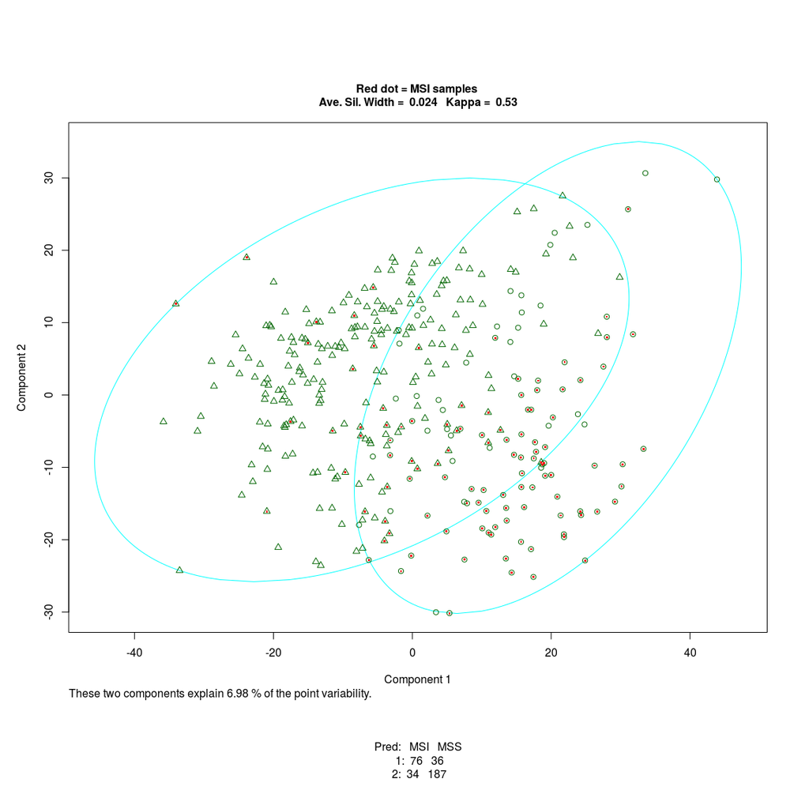

```r
###, results='hold'} this  r chunk option doesn't appear to work!
 suppressMessages(require(cluster))
 BestK <- as.numeric(sub('K_','', names(asw.vec)[which.max(asw.vec)]))

 # Make sure Expr.dist hasn't changed!
 Expr.pam <- pam(Expr.dist, k=BestK, keep.diss=T)

 # Look at agreement with MSS label
 Pam.agree.tbl <- table(Expr.pam$clustering, Train.Label.vec)

 # Compute kappa for display on figure
 # (Only makes sense for BestK==2)
 kappa.v <- NA
 if(BestK == 2) kappa.v <- getKappa(Expr.pam$clustering, Train.Label.vec)

 #######################################
 # Visualization
 #######################################
 old_par <- par(mfrow=c(1,1), oma=c(8,1,5,1), #mar=c(4.2, 3.2, 1.1, 0.2),
      #bg=rgb(0,0,.606),fg=7,col.axis=7,col.lab=7,col.main=7, col.sub=7,
       cex.main=1.0,cex.lab=1.0,cex.axis=1.0)

# DEBUG
#save(Expr.pam, file=file.path(WRKDIR,'Data', 'Expr.pam'))
#THIS DOEST WORK ANY MORE
SKIP <- function() {
   plot(Expr.pam,main='')
   mtext2by2Tbl(Pam.agree.tbl)
}# SKIP

 ###################################
 clusplot(Expr.pam, main='')###, pch=DataSource.pch)

 ### Recolor samples according to MSS/MSI status
 #xD <- eval(Expr.pam$call[[2]])
 xD <- Expr.pam$diss
 x1 <- cmdscale(xD, k=2, eig=T, add=T)
 if(x1$ac < 0)
    x1 <- cmdscale(xD, k=2, eig=T)
 #var.dec <- x1$GOF[2]
 x1 <- x1$points

 points(x1[,1][Train.Label.vec=='MSI'], x1[,2][Train.Label.vec=='MSI'],
         pch='.',cex=3, col='red')
 # add 2x2 tbale in margin
 mtext2by2Tbl(Pam.agree.tbl)

 title(paste('Red dot = MSI samples',
  '\nAve. Sil. Width = ', round(Expr.pam$silinfo$avg.width,3),
  '  Kappa = ', round(kappa.v,3)))
```

```r
 par(old_par)
```

Although the MSS and MSI somewhat colocate on the two dimensional projection of their gene expression vectors, one would be hard-pressed to make the case that clusters exist in these data. Next we’ll see if bootstrap aggregation helps.

## 6.2 Bootstrap Aggregation of Clusters

Next we will implement the baaged clustering procedure, BagClust2:

For a fixed number of clusters K:

1. Initialize matrices $A_{nxn}$ and $M_{nxn}$ to zeroes.

Repeat 2-4 N_BOOT times:

```
2. Form the $b^{th}$ bootstrap sample, Bt_Samp
3. Cluster Bt_Samp to obtain cluster labels Bt_Clust
4. For each pair of samples in Bt_Samp, s1, s2
    - increment $M_{s1,s1}$
    - increment $A_{s1,s1}$ if s1 and s2 co-cluster in the $b^{th}$ bootstarp sample.
```

end repeat.

5. Define a new dissimilarity matrix $D = 1 - A/M$
6. Cluster samples on the basis of this dissimilarity matrix.

```r
 suppressMessages(require(cluster))
 suppressMessages(require(stats))

 N_BOOT <- 30

 # initialize list to store BagCLust results
 SelGenes.BagClust.pam.lst <- list()

 for(KK in 2:5) {
  # Initialize counting matrices
  A.mtx <- matrix(0, ncol=length(Train.Label.vec),
                     nrow=length(Train.Label.vec))
  rownames(A.mtx) <- names(Train.Label.vec)
  colnames(A.mtx) <- names(Train.Label.vec)

  M.mtx <- matrix(0, ncol=length(Train.Label.vec),
                     nrow=length(Train.Label.vec))
  rownames(M.mtx) <- names(Train.Label.vec)
  colnames(M.mtx) <- names(Train.Label.vec)


  # Repeat 2-4 B times
  # 2. Form the b_th bootstrap sample Bt_Samp =
  #       sample(Samp.vec, size=N_Samp, replace=T)
  # 3. Cluster to obtain cluster labels Bt_Clust for samples in Bt_Samp
  # 4. For each pair of samples in Bt_Samp, s1, s2,
  #     - increment M[s1,s2]
  #     - increment A[s1,s1] if Bt_Clust[s1] == Bt_Clust[2]
  # end repeat
  for(BB in 1:N_BOOT){
   cat('.')
   # 2. form the BS sample
   B_Samp <- sample(names(Train.Label.vec), size=length(Train.Label.vec), replace=T)

   Expr.B.mtx <- Expr.mtx[B_Samp,]

   # Get dissimilarity
   {if(DM == "1-pearson")
     Expr.B.dist <- as.dist(1-cor(t(Expr.B.mtx))) else
     Expr.B.dist <- daisy(Expr.B.mtx, DM)
   }
   rm(Expr.B.mtx)

   # 3. cluster
   Expr.B.pam <- pam(Expr.B.dist, k=KK)

   # 4. For each pair of samples in Bt_Samp, s1, s2,
   #     - increment M[s1,s2]
   #     - increment A[s1,s1] if Bt_Clust[s1] == Bt_Clust[2]
   B_Samp.lst <- unique(B_Samp)

   M.mtx[B_Samp.lst, B_Samp.lst] <-   M.mtx[B_Samp.lst, B_Samp.lst] + 1

   # patition in list
   B_Samp.Cluster <- Expr.B.pam$clustering[B_Samp.lst]
   B_Samp.Clust.lst <- split(B_Samp.lst, B_Samp.Cluster)

   for(LL in 1:length(B_Samp.Clust.lst)) {
    Clust.Samp <- B_Samp.Clust.lst[[LL]]
    A.mtx[Clust.Samp, Clust.Samp] <-   A.mtx[Clust.Samp, Clust.Samp] + 1
   }
  } # end BB loop
  cat('\n')

  # 5. Define new dissimilariy matirx D = 1 - A/M
  D.mtx <- A.mtx/M.mtx
  D.mtx[is.na(D.mtx)] <- 0

  # 6. Cluster observations on the basis of this dissimilarity matrix
  D.dist <- as.dist(1-D.mtx)
  SelGenes.BagClust.pam.lst[[paste0('K_',KK)]] <- pam(D.dist, k=KK, keep.diss=T)
  cat('KK =',KK, '   sil.avg.width =', SelGenes.BagClust.pam.lst[[paste0('K_',KK)]]$silinfo$avg.width, '\n')
 }#for(KK
```

```
## ..............................
## KK = 2    sil.avg.width = 0.8019623
## ..............................
## KK = 3    sil.avg.width = 0.6664015
## ..............................
## KK = 4    sil.avg.width = 0.3214489
## ..............................
## KK = 5    sil.avg.width = 0.271282
```

```r
 ## save
 saveObj(paste0(SelGenes, '.BagClust.pam.lst'), 'SelGenes.BagClust.pam.lst')
```

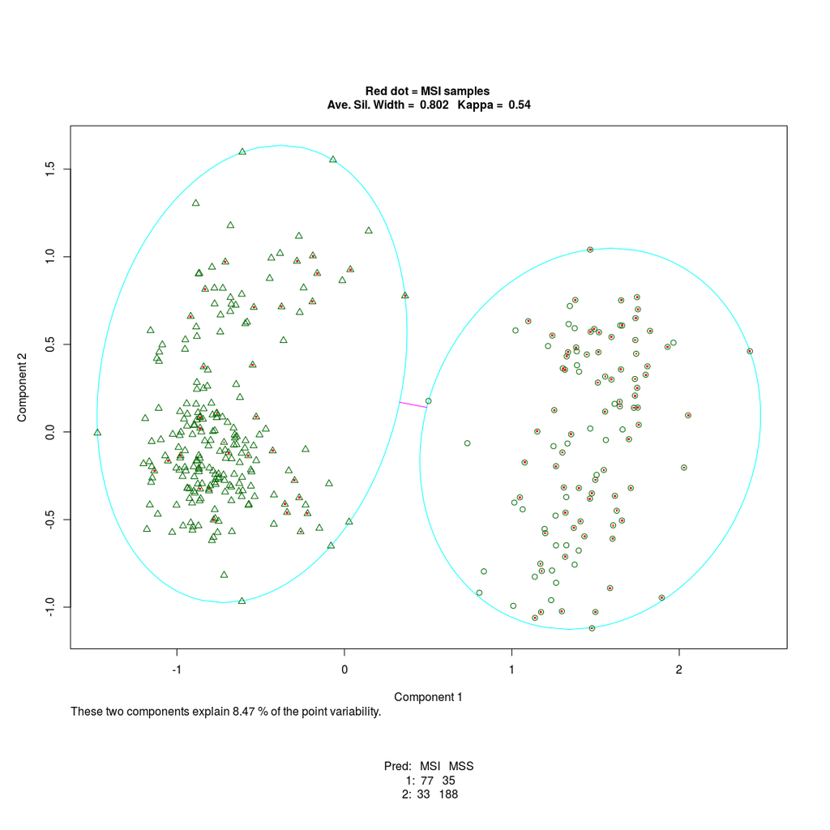

```r
 suppressMessages(require(cluster))

 loadObj(paste0(SelGenes, '.BagClust.pam.lst'), 'SelGenes.BagClust.pam.lst')

 # Get best K model
 BagClustBestK <- names(SelGenes.BagClust.pam.lst)[which.max(sapply(SelGenes.BagClust.pam.lst,
  function(x) x$silinfo$avg.width))]

 BagClustBestK.pam <- SelGenes.BagClust.pam.lst[[BagClustBestK]]

 # Get agreement table
 BagClustBestK.pam.agree.tbl <- table(BagClustBestK.pam$clustering, Train.Label.vec)

 #Compute kappa for display on figure
 # (Only makes sense for KK==2)
 if(BagClustBestK == paste0('K_',2))
 kappa.v <- getKappa(BagClustBestK.pam$clustering, Train.Label.vec)
 #cat('kappa =', kappa.v, '\n')

 #######################################
 # Visualization
 #######################################
 old_par <- par(mfrow=c(1,1), oma=c(8,1,5,1), #mar=c(4.2, 3.2, 1.1, 0.2),
      #bg=rgb(0,0,.606),fg=7,col.axis=7,col.lab=7,col.main=7, col.sub=7,
       cex.main=1.0,cex.lab=1.0,cex.axis=1.0)

 #plot(BagClustBestK.pam,main='')

 clusplot(BagClustBestK.pam, main='')###, pch=DataSource.pch)

 ### Recolor samples according to MSS/MSI status
 #xD <- eval(BagClustBestK.pam$call[[2]])
 xD <- BagClustBestK.pam$diss
 x1 <- cmdscale(xD, k=2, eig=T, add=T)
 if(x1$ac < 0)
    x1 <- cmdscale(xD, k=2, eig=T)
 #var.dec <- x1$GOF[2]
 x1 <- x1$points

 points(x1[,1][Train.Label.vec=='MSI'], x1[,2][Train.Label.vec=='MSI'],
         pch='.',cex=3, col='red')

 # add 2x2 tbale in margin
 mtext2by2Tbl(BagClustBestK.pam.agree.tbl)

 title(paste('Red dot = MSI samples',
  '\nAve. Sil. Width = ', round(BagClustBestK.pam$silinfo$avg.width,3),
  '  Kappa = ', round(kappa.v,3)))
```

```r
 par(old_par)
```

The groupings discovered by BagClust2 are essentially the same as those discovered by the PAM cluster analysis. The main effect of the bagging is to reduce noise and provide better separation between groups, which greatly increases our confidence in the groupings.

Next we look at the application of t-SNE algorithm to this problem.

## 6.3 t-SNE

t-SNE is a dimensionality reduction techique that is particularly well suited for the visualization of high-dimensional datasets. Here we will use the t-SNE algorithm to reduce the gene expression data martrix to a few dimensions. These will then be used as inputs to some clustering algorithm for the purpose of discovering subgroups in the data. Here we will assess the benefit of the t-SNE embedding by repeating the cluster analysis above - PAM and BagClust2 clustering - using the t-SNE embedding as input instead of the scales expression matrix.

```r
 # Load Data
 loadObj(paste0('Train.',SelGenes,'.vec'), 'SelGenes.vec')

 load(file=file.path(WRKDIR, 'Data', 'Train.Expr.mtx'))
 Train.SelGenes.Expr.mtx <- Train.Expr.mtx[, SelGenes.vec]
 rm(Train.Expr.mtx)

 load(file=file.path(WRKDIR, 'Data', 'Train.Label.vec'))
 load(file=file.path(WRKDIR, 'Data', 'Train.DataSource.vec'))
```

```r
 suppressMessages(require(Rtsne))
 PERP <- 50
 SelGenes.tsne.lst <- list()

 for(DD in c(2,5,10))
  SelGenes.tsne.lst[[paste0('D_', DD)]] <-
  Rtsne(Train.SelGenes.Expr.mtx, check_duplicates=FALSE,
        pca=TRUE, pca_center=T, pca_scale=T,
        perplexity=PERP, theta=0.0, dims=DD, max_iter = 5000)

 saveObj(paste0(SelGenes, '.tsne.lst'), 'SelGenes.tsne.lst')
```

### 6.3.1 t-SNE + PAM

```r
 suppressMessages(require(stats))
 suppressMessages(require(cluster))

 loadObj(paste0(SelGenes, '.tsne.lst'), 'SelGenes.tsne.lst')


 tsne.asw.mtx <- do.call('rbind', lapply(names(SelGenes.tsne.lst),
 function(DD) {
  Expr.mtx <- SelGenes.tsne.lst[[DD]]$Y

  # Standardize?
  #if(STAND) Expr.mtx <- scale(Expr.mtx)

  # Get dissimilarity
  {if(DM == "1-pearson")
    Expr.dist <- as.dist(1-cor(t(Expr.mtx))) else
    Expr.dist <- daisy(Expr.mtx, DM)
  }

  # get ave sil width for range of K
  asw.vec <- sapply(2:5, function(kk) pam(Expr.dist, diss=T, k=kk)$silinfo$avg.width)
  names(asw.vec) <- paste0('K_', 2:5)

  asw.vec}))
  rownames(tsne.asw.mtx) <- names(SelGenes.tsne.lst)

  print(round(tsne.asw.mtx,3))
```

```
##        K_2   K_3   K_4   K_5
## D_2  0.398 0.391 0.402 0.375
## D_5  0.328 0.290 0.310 0.289
## D_10 0.321 0.268 0.312 0.286
```

PAM clustering based on t-SNE embeddings of various dimensions does not return allow us to discriminate among the number of clusters based on average silhouette width. Let’s see what the 2-D scatters look like as well as the PAM clustering into two groups.

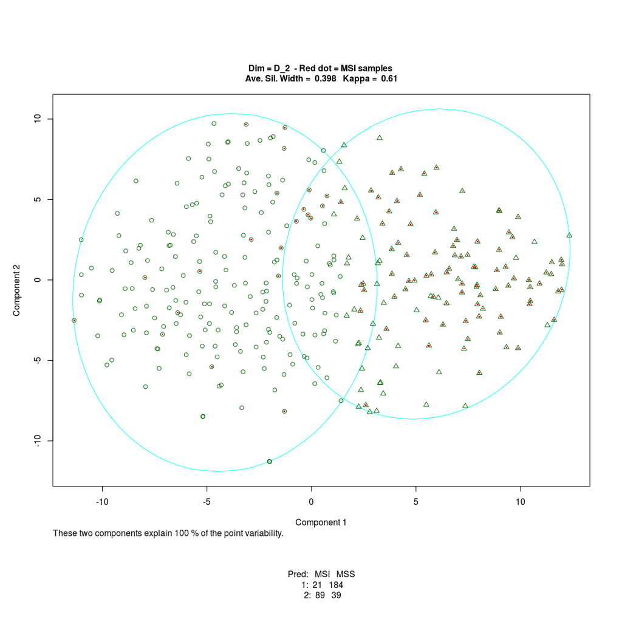

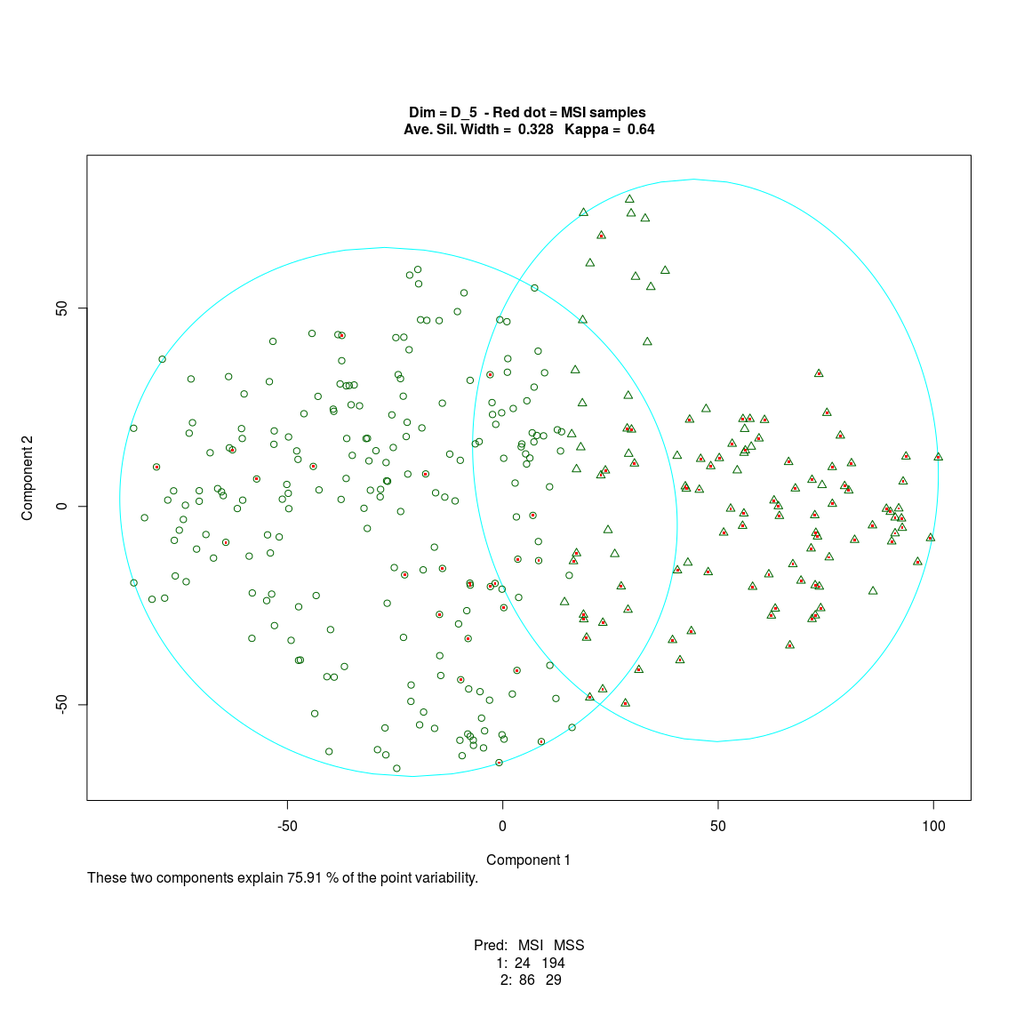

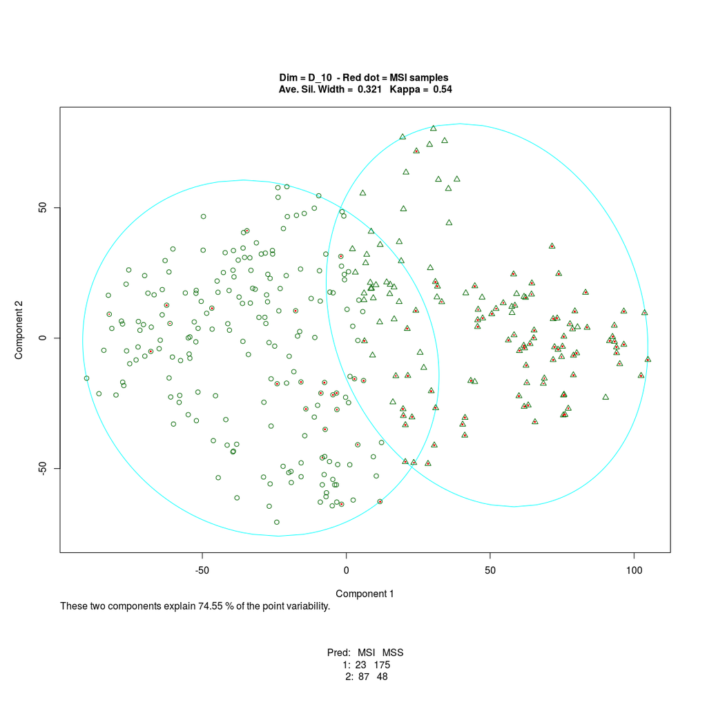

```r
 suppressMessages(require(cluster))
 loadObj(paste0(SelGenes, '.tsne.lst'), 'SelGenes.tsne.lst')

 for(DD in names(SelGenes.tsne.lst)){
  Expr.mtx <- SelGenes.tsne.lst[[DD]]$Y

  # Standardize?
  #if(STAND) Expr.mtx <- scale(Expr.mtx)

  # Get dissimilarity
  {if(DM == "1-pearson")
    Expr.dist <- as.dist(1-cor(t(Expr.mtx))) else
    Expr.dist <- daisy(Expr.mtx, DM)
  }

  #for(KK in 2:5) {
  KK <- 2
  Expr.pam <- pam(Expr.dist, diss=T, k=KK, keep.diss=T)
  Pam.agree.tbl <- table(Expr.pam$clustering, Train.Label.vec)
  kappa.v <- getKappa(Expr.pam$clustering, Train.Label.vec)

  #######################################
  # Visualization
  #######################################
  old_par <- par(mfrow=c(1,1), oma=c(8,1,5,1), #mar=c(4.2, 3.2, 1.1, 0.2),
      #bg=rgb(0,0,.606),fg=7,col.axis=7,col.lab=7,col.main=7, col.sub=7,
       cex.main=1.0,cex.lab=1.0,cex.axis=1.0)

  #plot(Expr.pam,main='')

  ###################################
  clusplot(Expr.pam, main='')###, pch=DataSource.pch)

  ### Recolor samples according to MSS/MSI status
  #xD <- eval(Expr.pam$call[[2]])
  xD <- Expr.pam$diss
  x1 <- cmdscale(xD, k=2, eig=T, add=T)
  if(x1$ac < 0)
     x1 <- cmdscale(xD, k=2, eig=T)
  #var.dec <- x1$GOF[2]
  x1 <- x1$points

  points(x1[,1][Train.Label.vec=='MSI'], x1[,2][Train.Label.vec=='MSI'],
          pch='.',cex=3, col='red')

  # add 2x2 tbale in margin
  mtext2by2Tbl(Pam.agree.tbl)

 title(paste('Dim =', DD, ' - Red dot = MSI samples',
  '\nAve. Sil. Width = ', round(Expr.pam$silinfo$avg.width,3),
  '  Kappa = ', round(kappa.v,3)))

  par(old_par)

 }#for(DD
```

PAM applied to t-SNE embeddings produce larger silhuoette profiles than PAM applied to the gene expression data. Let’s see how bagging helps here.

### 6.3.2 t-SNE + BagClust2

An important parameter in the application of t-SNE to clustering is the number of dimensions used in the t-SNE embedding. We will assess the effect of this parameter here, keeping the specified number of clusters fixed at k=2 while varying the number of embedding dimensions.

```r
 suppressMessages(require(cluster))
 suppressMessages(require(stats))

 KK <- 2

 loadObj(paste0(SelGenes, '.tsne.lst'), 'SelGenes.tsne.lst')
 load(file=file.path(WRKDIR, 'Data', 'Train.Label.vec'))

 N_BOOT <- 30

 # initialize list to store BagCLust results
 SelGenes.tsneBagClust.pam.lst <- list()

 for(DD in names(SelGenes.tsne.lst)){
  Expr.mtx <- SelGenes.tsne.lst[[DD]]$Y

  # Add rownames (assuming order is correct!)
  rownames(Expr.mtx) <- names(Train.Label.vec)

  # Initialize counting matrices
  A.mtx <- matrix(0, ncol=length(Train.Label.vec),
                     nrow=length(Train.Label.vec))
  rownames(A.mtx) <- names(Train.Label.vec)
  colnames(A.mtx) <- names(Train.Label.vec)

  M.mtx <- matrix(0, ncol=length(Train.Label.vec),
                     nrow=length(Train.Label.vec))
  rownames(M.mtx) <- names(Train.Label.vec)
  colnames(M.mtx) <- names(Train.Label.vec)


  # Repeat 2-4 B times
  # 2. Form the b_th bootstrap sample Bt_Samp =
  #       sample(Samp.vec, size=N_Samp, replace=T)
  # 3. Cluster to obtain cluster labels Bt_Clust for samples in Bt_Samp
  # 4. For each pair of samples in Bt_Samp, s1, s2,
  #     - increment M[s1,s2]
  #     - increment A[s1,s1] if Bt_Clust[s1] == Bt_Clust[2]
  # end repeat
  for(BB in 1:N_BOOT){
   cat('.')
   # 2. form the BS sample
   B_Samp <- sample(names(Train.Label.vec), size=length(Train.Label.vec), replace=T)

   Expr.B.mtx <- Expr.mtx[B_Samp,]

   # Get dissimilarity
   {if(DM == "1-pearson")
     Expr.B.dist <- as.dist(1-cor(t(Expr.B.mtx))) else
     Expr.B.dist <- daisy(Expr.B.mtx, DM)
   }
   rm(Expr.B.mtx)

   # 3. cluster
   Expr.B.pam <- pam(Expr.B.dist, k=KK)

   # 4. For each pair of samples in Bt_Samp, s1, s2,
   #     - increment M[s1,s2]
   #     - increment A[s1,s1] if Bt_Clust[s1] == Bt_Clust[2]
   B_Samp.lst <- unique(B_Samp)

   M.mtx[B_Samp.lst, B_Samp.lst] <-   M.mtx[B_Samp.lst, B_Samp.lst] + 1

   # patition in list
   B_Samp.Cluster <- Expr.B.pam$clustering[B_Samp.lst]
   B_Samp.Clust.lst <- split(B_Samp.lst, B_Samp.Cluster)

   for(LL in 1:length(B_Samp.Clust.lst)) {
    Clust.Samp <- B_Samp.Clust.lst[[LL]]
    A.mtx[Clust.Samp, Clust.Samp] <-   A.mtx[Clust.Samp, Clust.Samp] + 1
   }
  } # end BB loop
  cat('\n')

  # 5. Define new dissimilariy matirx D = 1 - A/M
  D.mtx <- A.mtx/M.mtx
  D.mtx[is.na(D.mtx)] <- 0

  # 6. Cluster observations on the basis of this dissimilarity matrix
  D.dist <- as.dist(1-D.mtx)
  SelGenes.tsneBagClust.pam.lst[[DD]] <- pam(D.dist, k=KK, keep.diss=T)
  cat('DD =',DD, '   sil.avg.width =', SelGenes.tsneBagClust.pam.lst[[DD]]$silinfo$avg.width, '\n')

 }#for(DD
```

```
## ..............................
## DD = D_2    sil.avg.width = 0.9042078
## ..............................
## DD = D_5    sil.avg.width = 0.8715593
## ..............................
## DD = D_10    sil.avg.width = 0.8852669
```

```r
 ## save
 saveObj(paste0(SelGenes, '.tsneBagClust.pam.lst'), 'SelGenes.tsneBagClust.pam.lst')
```

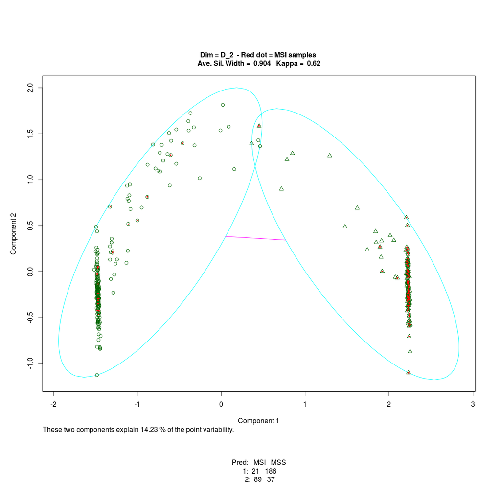

```r
 suppressMessages(require(cluster))

 loadObj(paste0(SelGenes, '.tsneBagClust.pam.lst'), 'SelGenes.tsneBagClust.pam.lst')
 load(file=file.path(WRKDIR, 'Data', 'Train.Label.vec'))

 # Get best K model
 BagClustBestD <- names(SelGenes.tsneBagClust.pam.lst)[which.max(sapply(SelGenes.tsneBagClust.pam.lst,
  function(x) x$silinfo$avg.width))]

 BagClustBestD.pam <- SelGenes.tsneBagClust.pam.lst[[BagClustBestD]]

 # Get agreement table
 BagClustBestD.pam.agree.tbl <- table(BagClustBestD.pam$clustering, Train.Label.vec)

 #Compute kappa for display on figure
 # (Only makes sense for KK==2)
 kappa.v <- getKappa(BagClustBestD.pam$clustering, Train.Label.vec)
 #cat('kappa =', kappa.v, '\n')

 #######################################
 # Visualization
 #######################################
 old_par <- par(mfrow=c(1,1), oma=c(8,1,5,1), #mar=c(4.2, 3.2, 1.1, 0.2),
      #bg=rgb(0,0,.606),fg=7,col.axis=7,col.lab=7,col.main=7, col.sub=7,
       cex.main=1.0,cex.lab=1.0,cex.axis=1.0)

 #plot(BagClustBestD.pam,main='')

 ###################################
 clusplot(BagClustBestD.pam, main='')###, pch=DataSource.pch)

 ### Recolor samples according to MSS/MSI status
 #xD <- eval(BagClustBestD.pam$call[[2]])
 xD <- BagClustBestD.pam$diss
 x1 <- cmdscale(xD, k=2, eig=T, add=T)
 if(x1$ac < 0)
    x1 <- cmdscale(xD, k=2, eig=T)
 #var.dec <- x1$GOF[2]
 x1 <- x1$points

 points(x1[,1][Train.Label.vec=='MSI'], x1[,2][Train.Label.vec=='MSI'],
         pch='.',cex=3, col='red')
  # add 2x2 tbale in margin
  mtext2by2Tbl(BagClustBestD.pam.agree.tbl)

 title(paste('Dim =', BagClustBestD, ' - Red dot = MSI samples',
  '\nAve. Sil. Width = ', round(BagClustBestD.pam$silinfo$avg.width,3),
  '  Kappa = ', round(kappa.v,3)))
```

```r
 par(old_par)
```

## 6.4 Cluster Analysis: Discussion

- The PAM algorithm does a decent job at “discovering” the MSS vs MSI grouping in an unsupervised analysis of the gene expression vectors. In this analysis, we restricted the analysis to the Top10VarGenes gene set. A different gene selection might give rise to sligthly different results.
- Bootstrap aggregation of PAM clustering results leads to cleaner separation among the groups but very little difference in the allocation of samples to groups. This is as expected. Bagging in thise case is a noise reduction measure.
- Applying the t-SNE algorithm to extract low dimensional embeddings of the gene expression vectors and applying the PAM algorthim to these data leads to some improved clustering results: separation of the groups is larger than is the results of applying PAM directly to the gene expression data.
- Bootstrap aggregation of results of applying PAM clustering to t-SNE embeddings leads to improved separation between groups and a slight improvement in the coherence between clusters and MSS vs MSI labels.

It appears that both t-SNE embeddings and bootstrap aggregation are helpful in producing better separated clusters in this context. We have only skimmed the surface of cluster analysis of gene expression data in this vignette. We did not look at the propensity of the different approaches to produce fals positive results - the appearance of clusters when non exist. We also did not investigate the effect of the choice of value for the many parameters that can be adjusted in these analyses. In any given situation, the sensitivity of results produced by a method to changes in parameter settings or slight perturbations of the data is an important part of cluster analysis.

## 6.5 Next Step: Look for subgroups in the MSS population - an open biological question.

# 7 References

1. Guinney, J., Dienstmann, R., Wang, X., Reyniès, A. de, Schlicker, A., Soneson, C., Marisa, L., Roepman, P., Nyamundanda, G., and Angelino, P. *et al.* (2015–11AD). The consensus molecular subtypes of colorectal cancer. Nature medicine *21*, 1350–1356. Available at: http://www.ncbi.nlm.nih.gov/pmc/articles/PMC4636487/.

2. Boland, C.R., Thibodeau, S.N., Hamilton, S.R., Sidransky, D., Eshleman, J.R., Burt, R.W., Meltzer, S.J., Rodriguez-Bigas, M.A., Fodde, R., and Ranzani, G.N. *et al.* (1998–11AD). A national cancer institute workshop on microsatellite instability for cancer detection and familial predisposition: Development of international criteria for the determination of microsatellite instability in colorectal cancer. Cancer Research *58*, 5248. Available at: http://cancerres.aacrjournals.org/content/58/22/5248.abstract.

3. Lazar, C., Meganck, S., Taminau, J., Steenhoff, D., Coletta, A., Molter, C., Weiss-Solís, D.Y., Duque, R., Bersini, H., and Nowé, A. (2013–7AD). Batch effect removal methods for microarray gene expression data integration: A survey. Briefings in Bioinformatics *14*, 469–490. Available at: http://dx.doi.org/10.1093/bib/bbs037.

4. Bolstad, B.M., Irizarry, R.A., Åstrand, M., and Speed, T.P. (2003–1AD). A comparison of normalization methods for high density oligonucleotide array data based on variance and bias. Bioinformatics *19*, 185–193. Available at: http://dx.doi.org/10.1093/bioinformatics/19.2.185.

5. Gagnon-Bartsch, J.A., and Speed, T.P. (2012–7AD). Using control genes to correct for unwanted variation in microarray data. Biostatistics *13*, 539–552. Available at: http://dx.doi.org/10.1093/biostatistics/kxr034.

6. Leek, J.T., Johnson, W.E., Parker, H.S., Jaffe, A.E., and Storey, J.D. (2012–3AD). The sva package for removing batch effects and other unwanted variation in high-throughput experiments. Bioinformatics *28*, 882–883. Available at: http://dx.doi.org/10.1093/bioinformatics/bts034.

7. Irizarry, R.A., Bolstad, B.M., Collin, F., Cope, L.M., Hobbs, B., and Speed, T.P. (2003–2AD). Summaries of affymetrix geneChip probe level data. Nucleic Acids Research *31*, e15–e15. Available at: http://dx.doi.org/10.1093/nar/gng015.

8. Vihinen, M. (2012). How to evaluate performance of prediction methods? Measures and their interpretation in variation effect analysis. BMC Genomics *13*, S2–S2. Available at: http://www.ncbi.nlm.nih.gov/pmc/articles/PMC3303716/.

9. Watanabe, T., Kobunai, T., Toda, E., Yamamoto, Y., Kanazawa, T., Kazama, Y., Tanaka, J., Tanaka, T., Konishi, T., and Okayama, Y. *et al.* (2006–10AD). Distal colorectal cancers with microsatellite instability (mSI) display distinct gene expression profiles that are different from proximal mSI cancers. Cancer Research *66*, 9804. Available at: http://cancerres.aacrjournals.org/content/66/20/9804.abstract.

10. Jorissen, R.N., Lipton, L., Gibbs, P., Chapman, M., Desai, J., Jones, I.T., Yeatman, T.J., East, P., Tomlinson, I.P.M., and Verspaget, H.W. *et al.* (2008–12AD). DNA copy-number alterations underlie gene expression differences between microsatellite stable and unstable colorectal cancers. Clinical Cancer Research *14*, 8061. Available at: http://clincancerres.aacrjournals.org/content/14/24/8061.abstract.

11. Alhopuro, P., Sammalkorpi, H., Niittymäki, I., Biström, M., Raitila, A., Saharinen, J., Nousiainen, K., Lehtonen, H.J., Heliövaara, E., and Puhakka, J. *et al.* (2012). Candidate driver genes in microsatellite-unstable colorectal cancer. International Journal of Cancer *130*, 1558–1566. Available at: http://dx.doi.org/10.1002/ijc.26167.

12. Watanabe, T., Kobunai, T., Yamamoto, Y., Matsuda, K., Ishihara, S., Nozawa, K., Yamada, H., Hayama, T., Inoue, E., and Tamura, J. *et al.* (2012–6AD). Chromosomal instability (cIN) phenotype, cIN high or cIN low, predicts survival for colorectal cancer. Journal of Clinical Oncology *30*, 2256–2264. Available at: https://doi.org/10.1200/JCO.2011.38.6490.

13. Schlicker, A., Beran, G., Chresta, C.M., McWalter, G., Pritchard, A., Weston, S., Runswick, S., Davenport, S., Heathcote, K., and Castro, D.A. *et al.* (2012). Subtypes of primary colorectal tumors correlate with response to targeted treatment in colorectal cell lines. BMC Medical Genomics *5*, 66–66. Available at: http://www.ncbi.nlm.nih.gov/pmc/articles/PMC3543849/.

14. Barras, D., Missiaglia, E., Wirapati, P., Sieber, O.M., Jorissen, R.N., Love, C., Molloy, P.L., Jones, I.T., McLaughlin, S., and Gibbs, P. *et al.* (2017–1AD). $<$em$>$BRAF$<$/em$>$ $<$em$>$V600E$<$/em$>$ mutant colorectal cancer subtypes based on gene expression. Clinical Cancer Research *23*, 104. Available at: http://clincancerres.aacrjournals.org/content/23/1/104.abstract.

15. Kirzin, S., Marisa, L., Guimbaud, R., De Reynies, A., Legrain, M., Laurent-Puig, P., Cordelier, P., Pradère, B., Bonnet, D., and Meggetto, F. *et al.* (2014). Sporadic early-onset colorectal cancer is a specific sub-type of cancer: A morphological, molecular and genetics study. PLoS ONE *9*, e103159. Available at: http://www.ncbi.nlm.nih.gov/pmc/articles/PMC4118858/.

16. Schmit, S.L., Gollub, J., Shapero, M.H., Huang, S.-C., Rennert, H.S., Finn, A., Rennert, G., and Gruber, S.B. (2015–1AD). MicroRNA polymorphisms and risk of colorectal cancer. Cancer Epidemiology Biomarkers &amp; Prevention *24*, 65. Available at: http://cebp.aacrjournals.org/content/24/1/65.abstract.

17. Yagi, K., Akagi, K., Hayashi, H., Nagae, G., Tsuji, S., Isagawa, T., Midorikawa, Y., Nishimura, Y., Sakamoto, H., and Seto, Y. *et al.* (2010–1AD). Three dNA methylation epigenotypes in human colorectal cancer. Clinical Cancer Research *16*, 21. Available at: http://clincancerres.aacrjournals.org/content/16/1/21.abstract.

18. Laiho, P., Kokko, A., Vanharanta, S., Salovaara, R., Sammalkorpi, H., Jarvinen, H., Mecklin, J.-P., Karttunen, T.J., Tuppurainen, K., and Davalos, V. *et al.* (2006–7AD). Serrated carcinomas form a subclass of colorectal cancer with distinct molecular basis. Oncogene *26*, 312–320. Available at: http://dx.doi.org/10.1038/sj.onc.1209778.

19. Banerjea, A., Ahmed, S., Hands, R.E., Huang, F., Han, X., Shaw, P.M., Feakins, R., Bustin, S.A., and Dorudi, S. (2004). Colorectal cancers with microsatellite instability display mRNA expression signatures characteristic of increased immunogenicity. Molecular Cancer *3*, 21. Available at: http://dx.doi.org/10.1186/1476-4598-3-21.

20. Lanza, G., Ferracin, M., Gafà, R., Veronese, A., Spizzo, R., Pichiorri, F., Liu, C.-g., Calin, G.A., Croce, C.M., and Negrini, M. (2007). MRNA/microRNA gene expression profile in microsatellite unstable colorectal cancer. Molecular Cancer *6*, 54–54. Available at: http://www.ncbi.nlm.nih.gov/pmc/articles/PMC2048978/.

21. Jorissen, R.N., Gibbs, P., Christie, M., Prakash, S., Lipton, L., Desai, J., Kerr, D., Aaltonen, L.A., Arango, D., and Kruhøffer, M. *et al.* (2009–12AD). Metastasis-associated gene expression changes predict poor outcomes in patients with dukes’stage b and c colorectal cancer. Clinical cancer research : an official journal of the American Association for Cancer Research *15*, 7642–7651. Available at: http://www.ncbi.nlm.nih.gov/pmc/articles/PMC2920750/.

22. Koinuma, K., Yamashita, Y., Liu, W., Hatanaka, H., Kurashina, K., Wada, T., Takada, S., Kaneda, R., Choi, Y.L., and Fujiwara, S.-I. *et al.* (2005–10AD). Epigenetic silencing of aXIN2 in colorectal carcinoma with microsatellite instability. Oncogene *25*, 139–146. Available at: http://dx.doi.org/10.1038/sj.onc.1209009.

23. Kruhøffer, M., Jensen, J.L., Laiho, P., Dyrskjøt, L., Salovaara, R., Arango, D., Birkenkamp-Demtroder, K., Sørensen, F.B., Christensen, L.L., and Buhl, L. *et al.* (2005–6AD). Gene expression signatures for colorectal cancer microsatellite status and hNPCC. British Journal of Cancer *92*, 2240–2248. Available at: http://www.ncbi.nlm.nih.gov/pmc/articles/PMC2361815/.

24. Mori, Y., Selaru, F.M., Sato, F., Yin, J., Simms, L.A., Xu, Y., Olaru, A., Deacu, E., Wang, S., and Taylor, J.M. *et al.* (2003–8AD). The impact of microsatellite instability on the molecular phenotype of colorectal tumors. Cancer Research *63*, 4577. Available at: http://cancerres.aacrjournals.org/content/63/15/4577.abstract.

25. Verhaak, R.G., Hoadley, K.A., Purdom, E., Wang, V., Qi, Y., Wilkerson, M.D., Miller, C.R., Ding, L., Golub, T., and Mesirov, J.P. *et al.* (2010–1AD). An integrated genomic analysis identifies clinically relevant subtypes of glioblastoma characterized by abnormalities in pDGFRA, iDH1, eGFR and nF1. Cancer cell *17*, 98. Available at: http://www.ncbi.nlm.nih.gov/pmc/articles/PMC2818769/.

26. Kaufman, L., and Rousseeuw, P.J. (1990). Finding groups in data: An introduction to cluster analysis (John Wiley).

27. Dudoit, S., and Fridlyand, J. (2003–6AD). Bagging to improve the accuracy of a clustering procedure. Bioinformatics *19*, 1090–1099. Available at: http://dx.doi.org/10.1093/bioinformatics/btg038.

28. Li, H.G., Wu, G.Q., Hu, X.G., Zhang, J., Li, L., and Wu, X. (2011). K-means clustering with bagging and mapReduce. 2011 44th Hawaii International Conference on System Sciences, 1–8.

# 8 User defined functions used in this script:

- saveObj and loadObj are used to move objects between the file system and the workspace.
- getKappa computes Cohen’s kappa which we use as a measure of agreement between clutering results and labels.
- mtext2by2Tbl prints a 2 by 2 table below a plot.

# 9 Parameter settings

- WRKDIR = /mnt100/home/Dropbox/PredictiveModeling/CC/R/
- FN = M1A-CRC
- Scripts = Scripts
- EXT_DATA = /mnt100/home/Dropbox/PredictiveModeling/CC//extData
- RUN DATE = Tue Jul 18 04:22:18 2017